> **So, Today** We are going to complete WeRateDogs project. Have you ever heard about it? No? That's alright! I also heard about it recently. It doesn't matter If don't know anything about this. There are a lot sources you can learn about. Do you have a dog? If so, take its picture and tweet about its beatiful, funny or other special habits. WeRateDogs! Next winner may be your dog in the future, who knows!

# Wrangle and Analysis (WeRateDogs)

## Data Wrangling

### Data Wrangling includes Three steps

- **Gathering**
- **Assessing**
- **Cleaning**

> So, let's start our **Data Wrangling** step

## Gathering

- is a process of fetching data from different sources

```python
# for now we must import some library which we want to use
# if there is any any, we will import them on the go
import numpy as np
import pandas as pd
import tweepy
from tweepy import OAuthHandler
import json
from timeit import default_timer as timer
import matplotlib.pyplot as plt
import seaborn as sns
% matplotlib inline
```

**First dataset is ready for just loading to workspace, It has been saved into .csv file**

```python
# let's just load twitter-archive data and have a look what it looks like
twit_archive = pd.read_csv('twitter-archive-enhanced.csv')
twit_archive.head(3)
```

|  | tweet_id | in_reply_to_status_id | in_reply_to_user_id | timestamp | source | text | retweeted_status_id | retweeted_status_user_id | retweeted_status_timestamp | expanded_urls | rating_numerator | rating_denominator | name | doggo | floofer | pupper | puppo |
| --- | --- | --- | --- | --- | --- | --- | --- | --- | --- | --- | --- | --- | --- | --- | --- | --- | --- |
| 0 | 892420643555336193 | NaN | NaN | 2017-08-01 16:23:56 +0000 | <a href="http://twitter.com/download/iphone" r... | This is Phineas. He's a mystical boy. Only eve... | NaN | NaN | NaN | https://twitter.com/dog_rates/status/892420643... | 13 | 10 | Phineas | None | None | None | None |
| 1 | 892177421306343426 | NaN | NaN | 2017-08-01 00:17:27 +0000 | <a href="http://twitter.com/download/iphone" r... | This is Tilly. She's just checking pup on you.... | NaN | NaN | NaN | https://twitter.com/dog_rates/status/892177421... | 13 | 10 | Tilly | None | None | None | None |
| 2 | 891815181378084864 | NaN | NaN | 2017-07-31 00:18:03 +0000 | <a href="http://twitter.com/download/iphone" r... | This is Archie. He is a rare Norwegian Pouncin... | NaN | NaN | NaN | https://twitter.com/dog_rates/status/891815181... | 12 | 10 | Archie | None | None | None | None |

**The second dataset requires a little bit more hardwork, but it is relatively easy**

> We must load this dataset programmatically using **requests** library.

```python
# there we can load our second dataset which is image predictions of dogs and have a look at it
import requests

r = requests.get('https://d17h27t6h515a5.cloudfront.net/topher/2017/August/599fd2ad_image-predictions/image-predictions.tsv')

with open('image-predictions.tsv', mode = 'wb') as file:
    file.write(r.content)

img_preds = pd.read_csv('image-predictions.tsv', sep = '\t')
img_preds.head(3)
```

|  | tweet_id | jpg_url | img_num | p1 | p1_conf | p1_dog | p2 | p2_conf | p2_dog | p3 | p3_conf | p3_dog |
| --- | --- | --- | --- | --- | --- | --- | --- | --- | --- | --- | --- | --- |
| 0 | 666020888022790149 | https://pbs.twimg.com/media/CT4udn0WwAA0aMy.jpg | 1 | Welsh_springer_spaniel | 0.465074 | True | collie | 0.156665 | True | Shetland_sheepdog | 0.061428 | True |
| 1 | 666029285002620928 | https://pbs.twimg.com/media/CT42GRgUYAA5iDo.jpg | 1 | redbone | 0.506826 | True | miniature_pinscher | 0.074192 | True | Rhodesian_ridgeback | 0.072010 | True |
| 2 | 666033412701032449 | https://pbs.twimg.com/media/CT4521TWwAEvMyu.jpg | 1 | German_shepherd | 0.596461 | True | malinois | 0.138584 | True | bloodhound | 0.116197 | True |

**And the final one** is much more difficult than the other two.

> You need to set up a twitter developer account. And then when you are approved, you are ready to dive into very interesting job. Using pythons **tweepy**, **json** libraries you can programmatically fetch the data into the workspace and manipulate it as a dataframe. Yeah, I can't create a developer account on twitter. So I used the Udacity hand out python code and .txt file which is result of this code. I provided the code below but I don't run this code. As it is useless if you don't have consumer keys. If you have one, you can run it using your own. You can do this replacing the word 'HIDDEN' by matching values respectively

```python
# At this point I must load our third data using tweepy
# But, I don't run this code because I have some problems on creating
# developer account on twitter
# if you want to run you must use your own consumer informations


# Query Twitter API for each tweet in the Twitter archive and save JSON in a text file
# These are hidden to comply with Twitter's API terms and conditions


#consumer_key = 'HIDDEN'
#consumer_secret = 'HIDDEN'
#access_token = 'HIDDEN'
#access_secret = 'HIDDEN'

#auth = OAuthHandler(consumer_key, consumer_secret)
#auth.set_access_token(access_token, access_secret)

#api = tweepy.API(auth, wait_on_rate_limit=True)


# NOTE TO STUDENT WITH MOBILE VERIFICATION ISSUES:
# df_1 is a DataFrame with the twitter_archive_enhanced.csv file. You may have to
# change line 17 to match the name of your DataFrame with twitter_archive_enhanced.csv
# NOTE TO REVIEWER: this student had mobile verification issues so the following
# Twitter API code was sent to this student from a Udacity instructor
# Tweet IDs for which to gather additional data via Twitter's API

#I will change the df_1 to twit_archive

#tweet_ids = twit_archive.tweet_id.values
#len(tweet_ids)


# Query Twitter's API for JSON data for each tweet ID in the Twitter archive


#count = 0
#fails_dict = {}
#start = timer()


# Save each tweet's returned JSON as a new line in a .txt file


#with open('tweet-json.txt', 'w') as outfile:

    # This loop will likely take 20-30 minutes to run because of Twitter's rate limit


#    for tweet_id in tweet_ids:
#        count += 1
#        print(str(count) + ": " + str(tweet_id))
#        try:
#            tweet = api.get_status(tweet_id, tweet_mode='extended')
#            print("Success")
#            json.dump(tweet._json, outfile)
#            outfile.write('\n')
#        except tweepy.TweepError as e:
#            print("Fail")
#            fails_dict[tweet_id] = e
#            pass
#end = timer()
#print(end - start)
#print(fails_dict)
```

```python
# we have given a tweet-json.txt file which is result of the code above
# now It is time to convert it a convinient dataframe and it will be helpful during next stages
tweets_data = []
with open('tweet-json.txt') as file:
    for line in file:
        try:
            tweet = json.loads(line)
            tweets_data.append(tweet)
        except:
            continue
twit_api = pd.DataFrame(tweets_data, columns=list(tweets_data[0].keys()))
```

```python
# now, let's have a look at its structrure a little bit
twit_api.head(3)
```

|  | created_at | id | id_str | full_text | truncated | display_text_range | entities | extended_entities | source | in_reply_to_status_id | ... | place | contributors | is_quote_status | retweet_count | favorite_count | favorited | retweeted | possibly_sensitive | possibly_sensitive_appealable | lang |
| --- | --- | --- | --- | --- | --- | --- | --- | --- | --- | --- | --- | --- | --- | --- | --- | --- | --- | --- | --- | --- | --- |
| 0 | Tue Aug 01 16:23:56 +0000 2017 | 892420643555336193 | 892420643555336193 | This is Phineas. He's a mystical boy. Only eve... | False | [0, 85] | {'hashtags': [], 'symbols': [], 'user_mentions... | {'media': [{'id': 892420639486877696, 'id_str'... | <a href="http://twitter.com/download/iphone" r... | NaN | ... | None | None | False | 8853 | 39467 | False | False | False | False | en |
| 1 | Tue Aug 01 00:17:27 +0000 2017 | 892177421306343426 | 892177421306343426 | This is Tilly. She's just checking pup on you.... | False | [0, 138] | {'hashtags': [], 'symbols': [], 'user_mentions... | {'media': [{'id': 892177413194625024, 'id_str'... | <a href="http://twitter.com/download/iphone" r... | NaN | ... | None | None | False | 6514 | 33819 | False | False | False | False | en |
| 2 | Mon Jul 31 00:18:03 +0000 2017 | 891815181378084864 | 891815181378084864 | This is Archie. He is a rare Norwegian Pouncin... | False | [0, 121] | {'hashtags': [], 'symbols': [], 'user_mentions... | {'media': [{'id': 891815175371796480, 'id_str'... | <a href="http://twitter.com/download/iphone" r... | NaN | ... | None | None | False | 4328 | 25461 | False | False | False | False | en |

3 rows × 27 columns

> **We have loaded all of our raw data, it looks like a somewhat untidy. Now it is time to write some notes about the issies they have got and make decisions about how we can handle them**

Ok! you are right! We've reached the second step of Data Wrangling processes.

# Assessing

- includes thinking like a detective and quickly spot some issues, and making decision about them. So, let's dive in!

## Visual Assesment

```python
# what about starting with visual assessment at first for each dataset
twit_archive
```

|  | tweet_id | in_reply_to_status_id | in_reply_to_user_id | timestamp | source | text | retweeted_status_id | retweeted_status_user_id | retweeted_status_timestamp | expanded_urls | rating_numerator | rating_denominator | name | doggo | floofer | pupper | puppo |
| --- | --- | --- | --- | --- | --- | --- | --- | --- | --- | --- | --- | --- | --- | --- | --- | --- | --- |
| 0 | 892420643555336193 | NaN | NaN | 2017-08-01 16:23:56 +0000 | <a href="http://twitter.com/download/iphone" r... | This is Phineas. He's a mystical boy. Only eve... | NaN | NaN | NaN | https://twitter.com/dog_rates/status/892420643... | 13 | 10 | Phineas | None | None | None | None |
| 1 | 892177421306343426 | NaN | NaN | 2017-08-01 00:17:27 +0000 | <a href="http://twitter.com/download/iphone" r... | This is Tilly. She's just checking pup on you.... | NaN | NaN | NaN | https://twitter.com/dog_rates/status/892177421... | 13 | 10 | Tilly | None | None | None | None |
| 2 | 891815181378084864 | NaN | NaN | 2017-07-31 00:18:03 +0000 | <a href="http://twitter.com/download/iphone" r... | This is Archie. He is a rare Norwegian Pouncin... | NaN | NaN | NaN | https://twitter.com/dog_rates/status/891815181... | 12 | 10 | Archie | None | None | None | None |
| 3 | 891689557279858688 | NaN | NaN | 2017-07-30 15:58:51 +0000 | <a href="http://twitter.com/download/iphone" r... | This is Darla. She commenced a snooze mid meal... | NaN | NaN | NaN | https://twitter.com/dog_rates/status/891689557... | 13 | 10 | Darla | None | None | None | None |
| 4 | 891327558926688256 | NaN | NaN | 2017-07-29 16:00:24 +0000 | <a href="http://twitter.com/download/iphone" r... | This is Franklin. He would like you to stop ca... | NaN | NaN | NaN | https://twitter.com/dog_rates/status/891327558... | 12 | 10 | Franklin | None | None | None | None |
| 5 | 891087950875897856 | NaN | NaN | 2017-07-29 00:08:17 +0000 | <a href="http://twitter.com/download/iphone" r... | Here we have a majestic great white breaching ... | NaN | NaN | NaN | https://twitter.com/dog_rates/status/891087950... | 13 | 10 | None | None | None | None | None |
| 6 | 890971913173991426 | NaN | NaN | 2017-07-28 16:27:12 +0000 | <a href="http://twitter.com/download/iphone" r... | Meet Jax. He enjoys ice cream so much he gets ... | NaN | NaN | NaN | https://gofundme.com/ydvmve-surgery-for-jax,ht... | 13 | 10 | Jax | None | None | None | None |
| 7 | 890729181411237888 | NaN | NaN | 2017-07-28 00:22:40 +0000 | <a href="http://twitter.com/download/iphone" r... | When you watch your owner call another dog a g... | NaN | NaN | NaN | https://twitter.com/dog_rates/status/890729181... | 13 | 10 | None | None | None | None | None |
| 8 | 890609185150312448 | NaN | NaN | 2017-07-27 16:25:51 +0000 | <a href="http://twitter.com/download/iphone" r... | This is Zoey. She doesn't want to be one of th... | NaN | NaN | NaN | https://twitter.com/dog_rates/status/890609185... | 13 | 10 | Zoey | None | None | None | None |
| 9 | 890240255349198849 | NaN | NaN | 2017-07-26 15:59:51 +0000 | <a href="http://twitter.com/download/iphone" r... | This is Cassie. She is a college pup. Studying... | NaN | NaN | NaN | https://twitter.com/dog_rates/status/890240255... | 14 | 10 | Cassie | doggo | None | None | None |
| 10 | 890006608113172480 | NaN | NaN | 2017-07-26 00:31:25 +0000 | <a href="http://twitter.com/download/iphone" r... | This is Koda. He is a South Australian decksha... | NaN | NaN | NaN | https://twitter.com/dog_rates/status/890006608... | 13 | 10 | Koda | None | None | None | None |
| 11 | 889880896479866881 | NaN | NaN | 2017-07-25 16:11:53 +0000 | <a href="http://twitter.com/download/iphone" r... | This is Bruno. He is a service shark. Only get... | NaN | NaN | NaN | https://twitter.com/dog_rates/status/889880896... | 13 | 10 | Bruno | None | None | None | None |
| 12 | 889665388333682689 | NaN | NaN | 2017-07-25 01:55:32 +0000 | <a href="http://twitter.com/download/iphone" r... | Here's a puppo that seems to be on the fence a... | NaN | NaN | NaN | https://twitter.com/dog_rates/status/889665388... | 13 | 10 | None | None | None | None | puppo |
| 13 | 889638837579907072 | NaN | NaN | 2017-07-25 00:10:02 +0000 | <a href="http://twitter.com/download/iphone" r... | This is Ted. He does his best. Sometimes that'... | NaN | NaN | NaN | https://twitter.com/dog_rates/status/889638837... | 12 | 10 | Ted | None | None | None | None |
| 14 | 889531135344209921 | NaN | NaN | 2017-07-24 17:02:04 +0000 | <a href="http://twitter.com/download/iphone" r... | This is Stuart. He's sporting his favorite fan... | NaN | NaN | NaN | https://twitter.com/dog_rates/status/889531135... | 13 | 10 | Stuart | None | None | None | puppo |
| 15 | 889278841981685760 | NaN | NaN | 2017-07-24 00:19:32 +0000 | <a href="http://twitter.com/download/iphone" r... | This is Oliver. You're witnessing one of his m... | NaN | NaN | NaN | https://twitter.com/dog_rates/status/889278841... | 13 | 10 | Oliver | None | None | None | None |
| 16 | 888917238123831296 | NaN | NaN | 2017-07-23 00:22:39 +0000 | <a href="http://twitter.com/download/iphone" r... | This is Jim. He found a fren. Taught him how t... | NaN | NaN | NaN | https://twitter.com/dog_rates/status/888917238... | 12 | 10 | Jim | None | None | None | None |
| 17 | 888804989199671297 | NaN | NaN | 2017-07-22 16:56:37 +0000 | <a href="http://twitter.com/download/iphone" r... | This is Zeke. He has a new stick. Very proud o... | NaN | NaN | NaN | https://twitter.com/dog_rates/status/888804989... | 13 | 10 | Zeke | None | None | None | None |
| 18 | 888554962724278272 | NaN | NaN | 2017-07-22 00:23:06 +0000 | <a href="http://twitter.com/download/iphone" r... | This is Ralphus. He's powering up. Attempting ... | NaN | NaN | NaN | https://twitter.com/dog_rates/status/888554962... | 13 | 10 | Ralphus | None | None | None | None |
| 19 | 888202515573088257 | NaN | NaN | 2017-07-21 01:02:36 +0000 | <a href="http://twitter.com/download/iphone" r... | RT @dog_rates: This is Canela. She attempted s... | 8.874740e+17 | 4.196984e+09 | 2017-07-19 00:47:34 +0000 | https://twitter.com/dog_rates/status/887473957... | 13 | 10 | Canela | None | None | None | None |
| 20 | 888078434458587136 | NaN | NaN | 2017-07-20 16:49:33 +0000 | <a href="http://twitter.com/download/iphone" r... | This is Gerald. He was just told he didn't get... | NaN | NaN | NaN | https://twitter.com/dog_rates/status/888078434... | 12 | 10 | Gerald | None | None | None | None |
| 21 | 887705289381826560 | NaN | NaN | 2017-07-19 16:06:48 +0000 | <a href="http://twitter.com/download/iphone" r... | This is Jeffrey. He has a monopoly on the pool... | NaN | NaN | NaN | https://twitter.com/dog_rates/status/887705289... | 13 | 10 | Jeffrey | None | None | None | None |
| 22 | 887517139158093824 | NaN | NaN | 2017-07-19 03:39:09 +0000 | <a href="http://twitter.com/download/iphone" r... | I've yet to rate a Venezuelan Hover Wiener. Th... | NaN | NaN | NaN | https://twitter.com/dog_rates/status/887517139... | 14 | 10 | such | None | None | None | None |
| 23 | 887473957103951883 | NaN | NaN | 2017-07-19 00:47:34 +0000 | <a href="http://twitter.com/download/iphone" r... | This is Canela. She attempted some fancy porch... | NaN | NaN | NaN | https://twitter.com/dog_rates/status/887473957... | 13 | 10 | Canela | None | None | None | None |
| 24 | 887343217045368832 | NaN | NaN | 2017-07-18 16:08:03 +0000 | <a href="http://twitter.com/download/iphone" r... | You may not have known you needed to see this ... | NaN | NaN | NaN | https://twitter.com/dog_rates/status/887343217... | 13 | 10 | None | None | None | None | None |
| 25 | 887101392804085760 | NaN | NaN | 2017-07-18 00:07:08 +0000 | <a href="http://twitter.com/download/iphone" r... | This... is a Jubilant Antarctic House Bear. We... | NaN | NaN | NaN | https://twitter.com/dog_rates/status/887101392... | 12 | 10 | None | None | None | None | None |
| 26 | 886983233522544640 | NaN | NaN | 2017-07-17 16:17:36 +0000 | <a href="http://twitter.com/download/iphone" r... | This is Maya. She's very shy. Rarely leaves he... | NaN | NaN | NaN | https://twitter.com/dog_rates/status/886983233... | 13 | 10 | Maya | None | None | None | None |
| 27 | 886736880519319552 | NaN | NaN | 2017-07-16 23:58:41 +0000 | <a href="http://twitter.com/download/iphone" r... | This is Mingus. He's a wonderful father to his... | NaN | NaN | NaN | https://www.gofundme.com/mingusneedsus,https:/... | 13 | 10 | Mingus | None | None | None | None |
| 28 | 886680336477933568 | NaN | NaN | 2017-07-16 20:14:00 +0000 | <a href="http://twitter.com/download/iphone" r... | This is Derek. He's late for a dog meeting. 13... | NaN | NaN | NaN | https://twitter.com/dog_rates/status/886680336... | 13 | 10 | Derek | None | None | None | None |
| 29 | 886366144734445568 | NaN | NaN | 2017-07-15 23:25:31 +0000 | <a href="http://twitter.com/download/iphone" r... | This is Roscoe. Another pupper fallen victim t... | NaN | NaN | NaN | https://twitter.com/dog_rates/status/886366144... | 12 | 10 | Roscoe | None | None | pupper | None |
| ... | ... | ... | ... | ... | ... | ... | ... | ... | ... | ... | ... | ... | ... | ... | ... | ... | ... |
| 2326 | 666411507551481857 | NaN | NaN | 2015-11-17 00:24:19 +0000 | <a href="http://twitter.com/download/iphone" r... | This is quite the dog. Gets really excited whe... | NaN | NaN | NaN | https://twitter.com/dog_rates/status/666411507... | 2 | 10 | quite | None | None | None | None |
| 2327 | 666407126856765440 | NaN | NaN | 2015-11-17 00:06:54 +0000 | <a href="http://twitter.com/download/iphone" r... | This is a southern Vesuvius bumblegruff. Can d... | NaN | NaN | NaN | https://twitter.com/dog_rates/status/666407126... | 7 | 10 | a | None | None | None | None |
| 2328 | 666396247373291520 | NaN | NaN | 2015-11-16 23:23:41 +0000 | <a href="http://twitter.com/download/iphone" r... | Oh goodness. A super rare northeast Qdoba kang... | NaN | NaN | NaN | https://twitter.com/dog_rates/status/666396247... | 9 | 10 | None | None | None | None | None |
| 2329 | 666373753744588802 | NaN | NaN | 2015-11-16 21:54:18 +0000 | <a href="http://twitter.com/download/iphone" r... | Those are sunglasses and a jean jacket. 11/10 ... | NaN | NaN | NaN | https://twitter.com/dog_rates/status/666373753... | 11 | 10 | None | None | None | None | None |
| 2330 | 666362758909284353 | NaN | NaN | 2015-11-16 21:10:36 +0000 | <a href="http://twitter.com/download/iphone" r... | Unique dog here. Very small. Lives in containe... | NaN | NaN | NaN | https://twitter.com/dog_rates/status/666362758... | 6 | 10 | None | None | None | None | None |
| 2331 | 666353288456101888 | NaN | NaN | 2015-11-16 20:32:58 +0000 | <a href="http://twitter.com/download/iphone" r... | Here we have a mixed Asiago from the Galápagos... | NaN | NaN | NaN | https://twitter.com/dog_rates/status/666353288... | 8 | 10 | None | None | None | None | None |
| 2332 | 666345417576210432 | NaN | NaN | 2015-11-16 20:01:42 +0000 | <a href="http://twitter.com/download/iphone" r... | Look at this jokester thinking seat belt laws ... | NaN | NaN | NaN | https://twitter.com/dog_rates/status/666345417... | 10 | 10 | None | None | None | None | None |
| 2333 | 666337882303524864 | NaN | NaN | 2015-11-16 19:31:45 +0000 | <a href="http://twitter.com/download/iphone" r... | This is an extremely rare horned Parthenon. No... | NaN | NaN | NaN | https://twitter.com/dog_rates/status/666337882... | 9 | 10 | an | None | None | None | None |
| 2334 | 666293911632134144 | NaN | NaN | 2015-11-16 16:37:02 +0000 | <a href="http://twitter.com/download/iphone" r... | This is a funny dog. Weird toes. Won't come do... | NaN | NaN | NaN | https://twitter.com/dog_rates/status/666293911... | 3 | 10 | a | None | None | None | None |
| 2335 | 666287406224695296 | NaN | NaN | 2015-11-16 16:11:11 +0000 | <a href="http://twitter.com/download/iphone" r... | This is an Albanian 3 1/2 legged Episcopalian... | NaN | NaN | NaN | https://twitter.com/dog_rates/status/666287406... | 1 | 2 | an | None | None | None | None |
| 2336 | 666273097616637952 | NaN | NaN | 2015-11-16 15:14:19 +0000 | <a href="http://twitter.com/download/iphone" r... | Can take selfies 11/10 https://t.co/ws2AMaNwPW | NaN | NaN | NaN | https://twitter.com/dog_rates/status/666273097... | 11 | 10 | None | None | None | None | None |
| 2337 | 666268910803644416 | NaN | NaN | 2015-11-16 14:57:41 +0000 | <a href="http://twitter.com/download/iphone" r... | Very concerned about fellow dog trapped in com... | NaN | NaN | NaN | https://twitter.com/dog_rates/status/666268910... | 10 | 10 | None | None | None | None | None |
| 2338 | 666104133288665088 | NaN | NaN | 2015-11-16 04:02:55 +0000 | <a href="http://twitter.com/download/iphone" r... | Not familiar with this breed. No tail (weird).... | NaN | NaN | NaN | https://twitter.com/dog_rates/status/666104133... | 1 | 10 | None | None | None | None | None |
| 2339 | 666102155909144576 | NaN | NaN | 2015-11-16 03:55:04 +0000 | <a href="http://twitter.com/download/iphone" r... | Oh my. Here you are seeing an Adobe Setter giv... | NaN | NaN | NaN | https://twitter.com/dog_rates/status/666102155... | 11 | 10 | None | None | None | None | None |
| 2340 | 666099513787052032 | NaN | NaN | 2015-11-16 03:44:34 +0000 | <a href="http://twitter.com/download/iphone" r... | Can stand on stump for what seems like a while... | NaN | NaN | NaN | https://twitter.com/dog_rates/status/666099513... | 8 | 10 | None | None | None | None | None |
| 2341 | 666094000022159362 | NaN | NaN | 2015-11-16 03:22:39 +0000 | <a href="http://twitter.com/download/iphone" r... | This appears to be a Mongolian Presbyterian mi... | NaN | NaN | NaN | https://twitter.com/dog_rates/status/666094000... | 9 | 10 | None | None | None | None | None |
| 2342 | 666082916733198337 | NaN | NaN | 2015-11-16 02:38:37 +0000 | <a href="http://twitter.com/download/iphone" r... | Here we have a well-established sunblockerspan... | NaN | NaN | NaN | https://twitter.com/dog_rates/status/666082916... | 6 | 10 | None | None | None | None | None |
| 2343 | 666073100786774016 | NaN | NaN | 2015-11-16 01:59:36 +0000 | <a href="http://twitter.com/download/iphone" r... | Let's hope this flight isn't Malaysian (lol). ... | NaN | NaN | NaN | https://twitter.com/dog_rates/status/666073100... | 10 | 10 | None | None | None | None | None |
| 2344 | 666071193221509120 | NaN | NaN | 2015-11-16 01:52:02 +0000 | <a href="http://twitter.com/download/iphone" r... | Here we have a northern speckled Rhododendron.... | NaN | NaN | NaN | https://twitter.com/dog_rates/status/666071193... | 9 | 10 | None | None | None | None | None |
| 2345 | 666063827256086533 | NaN | NaN | 2015-11-16 01:22:45 +0000 | <a href="http://twitter.com/download/iphone" r... | This is the happiest dog you will ever see. Ve... | NaN | NaN | NaN | https://twitter.com/dog_rates/status/666063827... | 10 | 10 | the | None | None | None | None |
| 2346 | 666058600524156928 | NaN | NaN | 2015-11-16 01:01:59 +0000 | <a href="http://twitter.com/download/iphone" r... | Here is the Rand Paul of retrievers folks! He'... | NaN | NaN | NaN | https://twitter.com/dog_rates/status/666058600... | 8 | 10 | the | None | None | None | None |
| 2347 | 666057090499244032 | NaN | NaN | 2015-11-16 00:55:59 +0000 | <a href="http://twitter.com/download/iphone" r... | My oh my. This is a rare blond Canadian terrie... | NaN | NaN | NaN | https://twitter.com/dog_rates/status/666057090... | 9 | 10 | a | None | None | None | None |
| 2348 | 666055525042405380 | NaN | NaN | 2015-11-16 00:49:46 +0000 | <a href="http://twitter.com/download/iphone" r... | Here is a Siberian heavily armored polar bear ... | NaN | NaN | NaN | https://twitter.com/dog_rates/status/666055525... | 10 | 10 | a | None | None | None | None |
| 2349 | 666051853826850816 | NaN | NaN | 2015-11-16 00:35:11 +0000 | <a href="http://twitter.com/download/iphone" r... | This is an odd dog. Hard on the outside but lo... | NaN | NaN | NaN | https://twitter.com/dog_rates/status/666051853... | 2 | 10 | an | None | None | None | None |
| 2350 | 666050758794694657 | NaN | NaN | 2015-11-16 00:30:50 +0000 | <a href="http://twitter.com/download/iphone" r... | This is a truly beautiful English Wilson Staff... | NaN | NaN | NaN | https://twitter.com/dog_rates/status/666050758... | 10 | 10 | a | None | None | None | None |
| 2351 | 666049248165822465 | NaN | NaN | 2015-11-16 00:24:50 +0000 | <a href="http://twitter.com/download/iphone" r... | Here we have a 1949 1st generation vulpix. Enj... | NaN | NaN | NaN | https://twitter.com/dog_rates/status/666049248... | 5 | 10 | None | None | None | None | None |
| 2352 | 666044226329800704 | NaN | NaN | 2015-11-16 00:04:52 +0000 | <a href="http://twitter.com/download/iphone" r... | This is a purebred Piers Morgan. Loves to Netf... | NaN | NaN | NaN | https://twitter.com/dog_rates/status/666044226... | 6 | 10 | a | None | None | None | None |
| 2353 | 666033412701032449 | NaN | NaN | 2015-11-15 23:21:54 +0000 | <a href="http://twitter.com/download/iphone" r... | Here is a very happy pup. Big fan of well-main... | NaN | NaN | NaN | https://twitter.com/dog_rates/status/666033412... | 9 | 10 | a | None | None | None | None |
| 2354 | 666029285002620928 | NaN | NaN | 2015-11-15 23:05:30 +0000 | <a href="http://twitter.com/download/iphone" r... | This is a western brown Mitsubishi terrier. Up... | NaN | NaN | NaN | https://twitter.com/dog_rates/status/666029285... | 7 | 10 | a | None | None | None | None |
| 2355 | 666020888022790149 | NaN | NaN | 2015-11-15 22:32:08 +0000 | <a href="http://twitter.com/download/iphone" r... | Here we have a Japanese Irish Setter. Lost eye... | NaN | NaN | NaN | https://twitter.com/dog_rates/status/666020888... | 8 | 10 | None | None | None | None | None |

2356 rows × 17 columns

### archive data

- it looks like 'in_reply_to_status_id', 'in_reply_to_user_id', 'retweeted_status_id', 'retweeted_status_user_id', 'retweeted_status_timestamp' columns have got some non-null values, they all need to be null because non-null values refers to duplicated tweets.
- I think, 'source' column has got unnecessary HTML elements, we need to extract just its content
- 'name' column has also some issues like unproper words like 'None', 'a', 'the', 'such', etc. We need to fix them or something else.
- 'doggo', 'floofer', 'pupper' and 'puppo' columns also need to be added one column, because they are related to one variable.
- 'text' column also includes miltiple variables. One column must contain one variable.
- 'rating_numerator' and 'rating_denominator' refers to one variable but they are in two different columns

```python
# let's do visual assessment for predictions data
img_preds
```

|  | tweet_id | jpg_url | img_num | p1 | p1_conf | p1_dog | p2 | p2_conf | p2_dog | p3 | p3_conf | p3_dog |
| --- | --- | --- | --- | --- | --- | --- | --- | --- | --- | --- | --- | --- |
| 0 | 666020888022790149 | https://pbs.twimg.com/media/CT4udn0WwAA0aMy.jpg | 1 | Welsh_springer_spaniel | 0.465074 | True | collie | 0.156665 | True | Shetland_sheepdog | 0.061428 | True |
| 1 | 666029285002620928 | https://pbs.twimg.com/media/CT42GRgUYAA5iDo.jpg | 1 | redbone | 0.506826 | True | miniature_pinscher | 0.074192 | True | Rhodesian_ridgeback | 0.072010 | True |
| 2 | 666033412701032449 | https://pbs.twimg.com/media/CT4521TWwAEvMyu.jpg | 1 | German_shepherd | 0.596461 | True | malinois | 0.138584 | True | bloodhound | 0.116197 | True |
| 3 | 666044226329800704 | https://pbs.twimg.com/media/CT5Dr8HUEAA-lEu.jpg | 1 | Rhodesian_ridgeback | 0.408143 | True | redbone | 0.360687 | True | miniature_pinscher | 0.222752 | True |
| 4 | 666049248165822465 | https://pbs.twimg.com/media/CT5IQmsXIAAKY4A.jpg | 1 | miniature_pinscher | 0.560311 | True | Rottweiler | 0.243682 | True | Doberman | 0.154629 | True |
| 5 | 666050758794694657 | https://pbs.twimg.com/media/CT5Jof1WUAEuVxN.jpg | 1 | Bernese_mountain_dog | 0.651137 | True | English_springer | 0.263788 | True | Greater_Swiss_Mountain_dog | 0.016199 | True |
| 6 | 666051853826850816 | https://pbs.twimg.com/media/CT5KoJ1WoAAJash.jpg | 1 | box_turtle | 0.933012 | False | mud_turtle | 0.045885 | False | terrapin | 0.017885 | False |
| 7 | 666055525042405380 | https://pbs.twimg.com/media/CT5N9tpXIAAifs1.jpg | 1 | chow | 0.692517 | True | Tibetan_mastiff | 0.058279 | True | fur_coat | 0.054449 | False |
| 8 | 666057090499244032 | https://pbs.twimg.com/media/CT5PY90WoAAQGLo.jpg | 1 | shopping_cart | 0.962465 | False | shopping_basket | 0.014594 | False | golden_retriever | 0.007959 | True |
| 9 | 666058600524156928 | https://pbs.twimg.com/media/CT5Qw94XAAA_2dP.jpg | 1 | miniature_poodle | 0.201493 | True | komondor | 0.192305 | True | soft-coated_wheaten_terrier | 0.082086 | True |
| 10 | 666063827256086533 | https://pbs.twimg.com/media/CT5Vg_wXIAAXfnj.jpg | 1 | golden_retriever | 0.775930 | True | Tibetan_mastiff | 0.093718 | True | Labrador_retriever | 0.072427 | True |
| 11 | 666071193221509120 | https://pbs.twimg.com/media/CT5cN_3WEAAlOoZ.jpg | 1 | Gordon_setter | 0.503672 | True | Yorkshire_terrier | 0.174201 | True | Pekinese | 0.109454 | True |
| 12 | 666073100786774016 | https://pbs.twimg.com/media/CT5d9DZXAAALcwe.jpg | 1 | Walker_hound | 0.260857 | True | English_foxhound | 0.175382 | True | Ibizan_hound | 0.097471 | True |
| 13 | 666082916733198337 | https://pbs.twimg.com/media/CT5m4VGWEAAtKc8.jpg | 1 | pug | 0.489814 | True | bull_mastiff | 0.404722 | True | French_bulldog | 0.048960 | True |
| 14 | 666094000022159362 | https://pbs.twimg.com/media/CT5w9gUW4AAsBNN.jpg | 1 | bloodhound | 0.195217 | True | German_shepherd | 0.078260 | True | malinois | 0.075628 | True |
| 15 | 666099513787052032 | https://pbs.twimg.com/media/CT51-JJUEAA6hV8.jpg | 1 | Lhasa | 0.582330 | True | Shih-Tzu | 0.166192 | True | Dandie_Dinmont | 0.089688 | True |
| 16 | 666102155909144576 | https://pbs.twimg.com/media/CT54YGiWUAEZnoK.jpg | 1 | English_setter | 0.298617 | True | Newfoundland | 0.149842 | True | borzoi | 0.133649 | True |
| 17 | 666104133288665088 | https://pbs.twimg.com/media/CT56LSZWoAAlJj2.jpg | 1 | hen | 0.965932 | False | cock | 0.033919 | False | partridge | 0.000052 | False |
| 18 | 666268910803644416 | https://pbs.twimg.com/media/CT8QCd1WEAADXws.jpg | 1 | desktop_computer | 0.086502 | False | desk | 0.085547 | False | bookcase | 0.079480 | False |
| 19 | 666273097616637952 | https://pbs.twimg.com/media/CT8T1mtUwAA3aqm.jpg | 1 | Italian_greyhound | 0.176053 | True | toy_terrier | 0.111884 | True | basenji | 0.111152 | True |
| 20 | 666287406224695296 | https://pbs.twimg.com/media/CT8g3BpUEAAuFjg.jpg | 1 | Maltese_dog | 0.857531 | True | toy_poodle | 0.063064 | True | miniature_poodle | 0.025581 | True |
| 21 | 666293911632134144 | https://pbs.twimg.com/media/CT8mx7KW4AEQu8N.jpg | 1 | three-toed_sloth | 0.914671 | False | otter | 0.015250 | False | great_grey_owl | 0.013207 | False |
| 22 | 666337882303524864 | https://pbs.twimg.com/media/CT9OwFIWEAMuRje.jpg | 1 | ox | 0.416669 | False | Newfoundland | 0.278407 | True | groenendael | 0.102643 | True |
| 23 | 666345417576210432 | https://pbs.twimg.com/media/CT9Vn7PWoAA_ZCM.jpg | 1 | golden_retriever | 0.858744 | True | Chesapeake_Bay_retriever | 0.054787 | True | Labrador_retriever | 0.014241 | True |
| 24 | 666353288456101888 | https://pbs.twimg.com/media/CT9cx0tUEAAhNN_.jpg | 1 | malamute | 0.336874 | True | Siberian_husky | 0.147655 | True | Eskimo_dog | 0.093412 | True |
| 25 | 666362758909284353 | https://pbs.twimg.com/media/CT9lXGsUcAAyUFt.jpg | 1 | guinea_pig | 0.996496 | False | skunk | 0.002402 | False | hamster | 0.000461 | False |
| 26 | 666373753744588802 | https://pbs.twimg.com/media/CT9vZEYWUAAlZ05.jpg | 1 | soft-coated_wheaten_terrier | 0.326467 | True | Afghan_hound | 0.259551 | True | briard | 0.206803 | True |
| 27 | 666396247373291520 | https://pbs.twimg.com/media/CT-D2ZHWIAA3gK1.jpg | 1 | Chihuahua | 0.978108 | True | toy_terrier | 0.009397 | True | papillon | 0.004577 | True |
| 28 | 666407126856765440 | https://pbs.twimg.com/media/CT-NvwmW4AAugGZ.jpg | 1 | black-and-tan_coonhound | 0.529139 | True | bloodhound | 0.244220 | True | flat-coated_retriever | 0.173810 | True |
| 29 | 666411507551481857 | https://pbs.twimg.com/media/CT-RugiWIAELEaq.jpg | 1 | coho | 0.404640 | False | barracouta | 0.271485 | False | gar | 0.189945 | False |
| ... | ... | ... | ... | ... | ... | ... | ... | ... | ... | ... | ... | ... |
| 2045 | 886366144734445568 | https://pbs.twimg.com/media/DE0BTnQUwAApKEH.jpg | 1 | French_bulldog | 0.999201 | True | Chihuahua | 0.000361 | True | Boston_bull | 0.000076 | True |
| 2046 | 886680336477933568 | https://pbs.twimg.com/media/DE4fEDzWAAAyHMM.jpg | 1 | convertible | 0.738995 | False | sports_car | 0.139952 | False | car_wheel | 0.044173 | False |
| 2047 | 886736880519319552 | https://pbs.twimg.com/media/DE5Se8FXcAAJFx4.jpg | 1 | kuvasz | 0.309706 | True | Great_Pyrenees | 0.186136 | True | Dandie_Dinmont | 0.086346 | True |
| 2048 | 886983233522544640 | https://pbs.twimg.com/media/DE8yicJW0AAAvBJ.jpg | 2 | Chihuahua | 0.793469 | True | toy_terrier | 0.143528 | True | can_opener | 0.032253 | False |
| 2049 | 887101392804085760 | https://pbs.twimg.com/media/DE-eAq6UwAA-jaE.jpg | 1 | Samoyed | 0.733942 | True | Eskimo_dog | 0.035029 | True | Staffordshire_bullterrier | 0.029705 | True |
| 2050 | 887343217045368832 | https://pbs.twimg.com/ext_tw_video_thumb/88734... | 1 | Mexican_hairless | 0.330741 | True | sea_lion | 0.275645 | False | Weimaraner | 0.134203 | True |
| 2051 | 887473957103951883 | https://pbs.twimg.com/media/DFDw2tyUQAAAFke.jpg | 2 | Pembroke | 0.809197 | True | Rhodesian_ridgeback | 0.054950 | True | beagle | 0.038915 | True |
| 2052 | 887517139158093824 | https://pbs.twimg.com/ext_tw_video_thumb/88751... | 1 | limousine | 0.130432 | False | tow_truck | 0.029175 | False | shopping_cart | 0.026321 | False |
| 2053 | 887705289381826560 | https://pbs.twimg.com/media/DFHDQBbXgAEqY7t.jpg | 1 | basset | 0.821664 | True | redbone | 0.087582 | True | Weimaraner | 0.026236 | True |
| 2054 | 888078434458587136 | https://pbs.twimg.com/media/DFMWn56WsAAkA7B.jpg | 1 | French_bulldog | 0.995026 | True | pug | 0.000932 | True | bull_mastiff | 0.000903 | True |
| 2055 | 888202515573088257 | https://pbs.twimg.com/media/DFDw2tyUQAAAFke.jpg | 2 | Pembroke | 0.809197 | True | Rhodesian_ridgeback | 0.054950 | True | beagle | 0.038915 | True |
| 2056 | 888554962724278272 | https://pbs.twimg.com/media/DFTH_O-UQAACu20.jpg | 3 | Siberian_husky | 0.700377 | True | Eskimo_dog | 0.166511 | True | malamute | 0.111411 | True |
| 2057 | 888804989199671297 | https://pbs.twimg.com/media/DFWra-3VYAA2piG.jpg | 1 | golden_retriever | 0.469760 | True | Labrador_retriever | 0.184172 | True | English_setter | 0.073482 | True |
| 2058 | 888917238123831296 | https://pbs.twimg.com/media/DFYRgsOUQAARGhO.jpg | 1 | golden_retriever | 0.714719 | True | Tibetan_mastiff | 0.120184 | True | Labrador_retriever | 0.105506 | True |
| 2059 | 889278841981685760 | https://pbs.twimg.com/ext_tw_video_thumb/88927... | 1 | whippet | 0.626152 | True | borzoi | 0.194742 | True | Saluki | 0.027351 | True |
| 2060 | 889531135344209921 | https://pbs.twimg.com/media/DFg_2PVW0AEHN3p.jpg | 1 | golden_retriever | 0.953442 | True | Labrador_retriever | 0.013834 | True | redbone | 0.007958 | True |
| 2061 | 889638837579907072 | https://pbs.twimg.com/media/DFihzFfXsAYGDPR.jpg | 1 | French_bulldog | 0.991650 | True | boxer | 0.002129 | True | Staffordshire_bullterrier | 0.001498 | True |
| 2062 | 889665388333682689 | https://pbs.twimg.com/media/DFi579UWsAAatzw.jpg | 1 | Pembroke | 0.966327 | True | Cardigan | 0.027356 | True | basenji | 0.004633 | True |
| 2063 | 889880896479866881 | https://pbs.twimg.com/media/DFl99B1WsAITKsg.jpg | 1 | French_bulldog | 0.377417 | True | Labrador_retriever | 0.151317 | True | muzzle | 0.082981 | False |
| 2064 | 890006608113172480 | https://pbs.twimg.com/media/DFnwSY4WAAAMliS.jpg | 1 | Samoyed | 0.957979 | True | Pomeranian | 0.013884 | True | chow | 0.008167 | True |
| 2065 | 890240255349198849 | https://pbs.twimg.com/media/DFrEyVuW0AAO3t9.jpg | 1 | Pembroke | 0.511319 | True | Cardigan | 0.451038 | True | Chihuahua | 0.029248 | True |
| 2066 | 890609185150312448 | https://pbs.twimg.com/media/DFwUU__XcAEpyXI.jpg | 1 | Irish_terrier | 0.487574 | True | Irish_setter | 0.193054 | True | Chesapeake_Bay_retriever | 0.118184 | True |
| 2067 | 890729181411237888 | https://pbs.twimg.com/media/DFyBahAVwAAhUTd.jpg | 2 | Pomeranian | 0.566142 | True | Eskimo_dog | 0.178406 | True | Pembroke | 0.076507 | True |
| 2068 | 890971913173991426 | https://pbs.twimg.com/media/DF1eOmZXUAALUcq.jpg | 1 | Appenzeller | 0.341703 | True | Border_collie | 0.199287 | True | ice_lolly | 0.193548 | False |
| 2069 | 891087950875897856 | https://pbs.twimg.com/media/DF3HwyEWsAABqE6.jpg | 1 | Chesapeake_Bay_retriever | 0.425595 | True | Irish_terrier | 0.116317 | True | Indian_elephant | 0.076902 | False |
| 2070 | 891327558926688256 | https://pbs.twimg.com/media/DF6hr6BUMAAzZgT.jpg | 2 | basset | 0.555712 | True | English_springer | 0.225770 | True | German_short-haired_pointer | 0.175219 | True |
| 2071 | 891689557279858688 | https://pbs.twimg.com/media/DF_q7IAWsAEuuN8.jpg | 1 | paper_towel | 0.170278 | False | Labrador_retriever | 0.168086 | True | spatula | 0.040836 | False |
| 2072 | 891815181378084864 | https://pbs.twimg.com/media/DGBdLU1WsAANxJ9.jpg | 1 | Chihuahua | 0.716012 | True | malamute | 0.078253 | True | kelpie | 0.031379 | True |
| 2073 | 892177421306343426 | https://pbs.twimg.com/media/DGGmoV4XsAAUL6n.jpg | 1 | Chihuahua | 0.323581 | True | Pekinese | 0.090647 | True | papillon | 0.068957 | True |
| 2074 | 892420643555336193 | https://pbs.twimg.com/media/DGKD1-bXoAAIAUK.jpg | 1 | orange | 0.097049 | False | bagel | 0.085851 | False | banana | 0.076110 | False |

2075 rows × 12 columns

### predictions data

- some column names aren't descriptive and there are several predictions. We need to select appropriate one and drop other predictions
- After selecting right prediction we must change prediction column name to dog_breed.
- then we need to remove underscores on dog_breed values and change them more qualitive way.

```python
# now is the turn to API data for visual assessment
twit_api
```

|  | created_at | id | id_str | full_text | truncated | display_text_range | entities | extended_entities | source | in_reply_to_status_id | ... | place | contributors | is_quote_status | retweet_count | favorite_count | favorited | retweeted | possibly_sensitive | possibly_sensitive_appealable | lang |
| --- | --- | --- | --- | --- | --- | --- | --- | --- | --- | --- | --- | --- | --- | --- | --- | --- | --- | --- | --- | --- | --- |
| 0 | Tue Aug 01 16:23:56 +0000 2017 | 892420643555336193 | 892420643555336193 | This is Phineas. He's a mystical boy. Only eve... | False | [0, 85] | {'hashtags': [], 'symbols': [], 'user_mentions... | {'media': [{'id': 892420639486877696, 'id_str'... | <a href="http://twitter.com/download/iphone" r... | NaN | ... | None | None | False | 8853 | 39467 | False | False | False | False | en |
| 1 | Tue Aug 01 00:17:27 +0000 2017 | 892177421306343426 | 892177421306343426 | This is Tilly. She's just checking pup on you.... | False | [0, 138] | {'hashtags': [], 'symbols': [], 'user_mentions... | {'media': [{'id': 892177413194625024, 'id_str'... | <a href="http://twitter.com/download/iphone" r... | NaN | ... | None | None | False | 6514 | 33819 | False | False | False | False | en |
| 2 | Mon Jul 31 00:18:03 +0000 2017 | 891815181378084864 | 891815181378084864 | This is Archie. He is a rare Norwegian Pouncin... | False | [0, 121] | {'hashtags': [], 'symbols': [], 'user_mentions... | {'media': [{'id': 891815175371796480, 'id_str'... | <a href="http://twitter.com/download/iphone" r... | NaN | ... | None | None | False | 4328 | 25461 | False | False | False | False | en |
| 3 | Sun Jul 30 15:58:51 +0000 2017 | 891689557279858688 | 891689557279858688 | This is Darla. She commenced a snooze mid meal... | False | [0, 79] | {'hashtags': [], 'symbols': [], 'user_mentions... | {'media': [{'id': 891689552724799489, 'id_str'... | <a href="http://twitter.com/download/iphone" r... | NaN | ... | None | None | False | 8964 | 42908 | False | False | False | False | en |
| 4 | Sat Jul 29 16:00:24 +0000 2017 | 891327558926688256 | 891327558926688256 | This is Franklin. He would like you to stop ca... | False | [0, 138] | {'hashtags': [{'text': 'BarkWeek', 'indices': ... | {'media': [{'id': 891327551943041024, 'id_str'... | <a href="http://twitter.com/download/iphone" r... | NaN | ... | None | None | False | 9774 | 41048 | False | False | False | False | en |
| 5 | Sat Jul 29 00:08:17 +0000 2017 | 891087950875897856 | 891087950875897856 | Here we have a majestic great white breaching ... | False | [0, 138] | {'hashtags': [{'text': 'BarkWeek', 'indices': ... | {'media': [{'id': 891087942176911360, 'id_str'... | <a href="http://twitter.com/download/iphone" r... | NaN | ... | None | None | False | 3261 | 20562 | False | False | False | False | en |
| 6 | Fri Jul 28 16:27:12 +0000 2017 | 890971913173991426 | 890971913173991426 | Meet Jax. He enjoys ice cream so much he gets ... | False | [0, 140] | {'hashtags': [], 'symbols': [], 'user_mentions... | {'media': [{'id': 890971906207338496, 'id_str'... | <a href="http://twitter.com/download/iphone" r... | NaN | ... | None | None | False | 2158 | 12041 | False | False | False | False | en |
| 7 | Fri Jul 28 00:22:40 +0000 2017 | 890729181411237888 | 890729181411237888 | When you watch your owner call another dog a g... | False | [0, 118] | {'hashtags': [], 'symbols': [], 'user_mentions... | {'media': [{'id': 890729118844600320, 'id_str'... | <a href="http://twitter.com/download/iphone" r... | NaN | ... | None | None | False | 16716 | 56848 | False | False | False | False | en |
| 8 | Thu Jul 27 16:25:51 +0000 2017 | 890609185150312448 | 890609185150312448 | This is Zoey. She doesn't want to be one of th... | False | [0, 122] | {'hashtags': [{'text': 'BarkWeek', 'indices': ... | {'media': [{'id': 890609177319665665, 'id_str'... | <a href="http://twitter.com/download/iphone" r... | NaN | ... | None | None | False | 4429 | 28226 | False | False | False | False | en |
| 9 | Wed Jul 26 15:59:51 +0000 2017 | 890240255349198849 | 890240255349198849 | This is Cassie. She is a college pup. Studying... | False | [0, 133] | {'hashtags': [], 'symbols': [], 'user_mentions... | {'media': [{'id': 890240245463175168, 'id_str'... | <a href="http://twitter.com/download/iphone" r... | NaN | ... | None | None | False | 7711 | 32467 | False | False | False | False | en |
| 10 | Wed Jul 26 00:31:25 +0000 2017 | 890006608113172480 | 890006608113172480 | This is Koda. He is a South Australian decksha... | False | [0, 130] | {'hashtags': [{'text': 'BarkWeek', 'indices': ... | {'media': [{'id': 890006600089468928, 'id_str'... | <a href="http://twitter.com/download/iphone" r... | NaN | ... | None | None | False | 7624 | 31166 | False | False | False | False | en |
| 11 | Tue Jul 25 16:11:53 +0000 2017 | 889880896479866881 | 889880896479866881 | This is Bruno. He is a service shark. Only get... | False | [0, 107] | {'hashtags': [], 'symbols': [], 'user_mentions... | {'media': [{'id': 889880888800096258, 'id_str'... | <a href="http://twitter.com/download/iphone" r... | NaN | ... | None | None | False | 5156 | 28268 | False | False | False | False | en |
| 12 | Tue Jul 25 01:55:32 +0000 2017 | 889665388333682689 | 889665388333682689 | Here's a puppo that seems to be on the fence a... | False | [0, 106] | {'hashtags': [], 'symbols': [], 'user_mentions... | {'media': [{'id': 889665366129029120, 'id_str'... | <a href="http://twitter.com/download/iphone" r... | NaN | ... | None | None | False | 8538 | 38818 | False | False | False | False | en |
| 13 | Tue Jul 25 00:10:02 +0000 2017 | 889638837579907072 | 889638837579907072 | This is Ted. He does his best. Sometimes that'... | False | [0, 91] | {'hashtags': [], 'symbols': [], 'user_mentions... | {'media': [{'id': 889638825424826374, 'id_str'... | <a href="http://twitter.com/download/iphone" r... | NaN | ... | None | None | False | 4735 | 27672 | False | False | False | False | en |
| 14 | Mon Jul 24 17:02:04 +0000 2017 | 889531135344209921 | 889531135344209921 | This is Stuart. He's sporting his favorite fan... | False | [0, 118] | {'hashtags': [{'text': 'BarkWeek', 'indices': ... | {'media': [{'id': 889531127467266049, 'id_str'... | <a href="http://twitter.com/download/iphone" r... | NaN | ... | None | None | False | 2321 | 15359 | False | False | False | False | en |
| 15 | Mon Jul 24 00:19:32 +0000 2017 | 889278841981685760 | 889278841981685760 | This is Oliver. You're witnessing one of his m... | False | [0, 138] | {'hashtags': [{'text': 'BarkWeek', 'indices': ... | {'media': [{'id': 889278779352338437, 'id_str'... | <a href="http://twitter.com/download/iphone" r... | NaN | ... | None | None | False | 5637 | 25652 | False | False | False | False | en |
| 16 | Sun Jul 23 00:22:39 +0000 2017 | 888917238123831296 | 888917238123831296 | This is Jim. He found a fren. Taught him how t... | False | [0, 86] | {'hashtags': [], 'symbols': [], 'user_mentions... | {'media': [{'id': 888917229776945152, 'id_str'... | <a href="http://twitter.com/download/iphone" r... | NaN | ... | None | None | False | 4709 | 29611 | False | False | False | False | en |
| 17 | Sat Jul 22 16:56:37 +0000 2017 | 888804989199671297 | 888804989199671297 | This is Zeke. He has a new stick. Very proud o... | False | [0, 128] | {'hashtags': [], 'symbols': [], 'user_mentions... | {'media': [{'id': 888804981515575296, 'id_str'... | <a href="http://twitter.com/download/iphone" r... | NaN | ... | None | None | False | 4559 | 26080 | False | False | False | False | en |
| 18 | Sat Jul 22 00:23:06 +0000 2017 | 888554962724278272 | 888554962724278272 | This is Ralphus. He's powering up. Attempting ... | False | [0, 87] | {'hashtags': [], 'symbols': [], 'user_mentions... | {'media': [{'id': 888554915546542081, 'id_str'... | <a href="http://twitter.com/download/iphone" r... | NaN | ... | None | None | False | 3732 | 20290 | False | False | False | False | en |
| 19 | Thu Jul 20 16:49:33 +0000 2017 | 888078434458587136 | 888078434458587136 | This is Gerald. He was just told he didn't get... | False | [0, 127] | {'hashtags': [], 'symbols': [], 'user_mentions... | {'media': [{'id': 888078426338406400, 'id_str'... | <a href="http://twitter.com/download/iphone" r... | NaN | ... | None | None | False | 3653 | 22201 | False | False | False | False | en |
| 20 | Wed Jul 19 16:06:48 +0000 2017 | 887705289381826560 | 887705289381826560 | This is Jeffrey. He has a monopoly on the pool... | False | [0, 127] | {'hashtags': [], 'symbols': [], 'user_mentions... | {'media': [{'id': 887705281597243393, 'id_str'... | <a href="http://twitter.com/download/iphone" r... | NaN | ... | None | None | False | 5609 | 30779 | False | False | False | False | en |
| 21 | Wed Jul 19 03:39:09 +0000 2017 | 887517139158093824 | 887517139158093824 | I've yet to rate a Venezuelan Hover Wiener. Th... | False | [0, 108] | {'hashtags': [], 'symbols': [], 'user_mentions... | {'media': [{'id': 887517108413886465, 'id_str'... | <a href="http://twitter.com/download/iphone" r... | NaN | ... | None | None | False | 12082 | 46959 | True | False | False | False | en |
| 22 | Wed Jul 19 00:47:34 +0000 2017 | 887473957103951883 | 887473957103951883 | This is Canela. She attempted some fancy porch... | False | [0, 99] | {'hashtags': [], 'symbols': [], 'user_mentions... | {'media': [{'id': 887473949361045505, 'id_str'... | <a href="http://twitter.com/download/iphone" r... | NaN | ... | None | None | False | 18781 | 69871 | False | False | False | False | en |
| 23 | Tue Jul 18 16:08:03 +0000 2017 | 887343217045368832 | 887343217045368832 | You may not have known you needed to see this ... | False | [0, 88] | {'hashtags': [], 'symbols': [], 'user_mentions... | {'media': [{'id': 887343120832229379, 'id_str'... | <a href="http://twitter.com/download/iphone" r... | NaN | ... | None | None | False | 10737 | 34222 | False | False | False | False | en |
| 24 | Tue Jul 18 00:07:08 +0000 2017 | 887101392804085760 | 887101392804085760 | This... is a Jubilant Antarctic House Bear. We... | False | [0, 129] | {'hashtags': [], 'symbols': [], 'user_mentions... | {'media': [{'id': 887101385971384320, 'id_str'... | <a href="http://twitter.com/download/iphone" r... | NaN | ... | None | None | False | 6167 | 31061 | False | False | False | False | en |
| 25 | Mon Jul 17 16:17:36 +0000 2017 | 886983233522544640 | 886983233522544640 | This is Maya. She's very shy. Rarely leaves he... | False | [0, 101] | {'hashtags': [], 'symbols': [], 'user_mentions... | {'media': [{'id': 886983218871902208, 'id_str'... | <a href="http://twitter.com/download/iphone" r... | NaN | ... | None | None | False | 8084 | 35859 | False | False | False | False | en |
| 26 | Sun Jul 16 23:58:41 +0000 2017 | 886736880519319552 | 886736880519319552 | This is Mingus. He's a wonderful father to his... | False | [0, 121] | {'hashtags': [], 'symbols': [], 'user_mentions... | {'media': [{'id': 886736868116754432, 'id_str'... | <a href="http://twitter.com/download/iphone" r... | NaN | ... | None | None | False | 3443 | 12306 | False | False | False | False | en |
| 27 | Sun Jul 16 20:14:00 +0000 2017 | 886680336477933568 | 886680336477933568 | This is Derek. He's late for a dog meeting. 13... | False | [0, 71] | {'hashtags': [], 'symbols': [], 'user_mentions... | {'media': [{'id': 886680331239161856, 'id_str'... | <a href="http://twitter.com/download/iphone" r... | NaN | ... | None | None | False | 4610 | 22798 | False | False | False | False | en |
| 28 | Sat Jul 15 23:25:31 +0000 2017 | 886366144734445568 | 886366144734445568 | This is Roscoe. Another pupper fallen victim t... | False | [0, 131] | {'hashtags': [], 'symbols': [], 'user_mentions... | {'media': [{'id': 886366138128449536, 'id_str'... | <a href="http://twitter.com/download/iphone" r... | NaN | ... | None | None | False | 3316 | 21524 | False | False | False | False | en |
| 29 | Sat Jul 15 16:51:35 +0000 2017 | 886267009285017600 | 886267009285017600 | @NonWhiteHat @MayhewMayhem omg hello tanner yo... | False | [27, 105] | {'hashtags': [], 'symbols': [], 'user_mentions... | NaN | <a href="http://twitter.com/download/iphone" r... | 8.862664e+17 | ... | None | None | False | 4 | 117 | False | False | NaN | NaN | en |
| ... | ... | ... | ... | ... | ... | ... | ... | ... | ... | ... | ... | ... | ... | ... | ... | ... | ... | ... | ... | ... | ... |
| 2324 | Tue Nov 17 00:24:19 +0000 2015 | 666411507551481857 | 666411507551481857 | This is quite the dog. Gets really excited whe... | False | [0, 140] | {'hashtags': [], 'symbols': [], 'user_mentions... | {'media': [{'id': 666411498068123649, 'id_str'... | <a href="http://twitter.com/download/iphone" r... | NaN | ... | None | None | False | 339 | 459 | False | False | False | False | en |
| 2325 | Tue Nov 17 00:06:54 +0000 2015 | 666407126856765440 | 666407126856765440 | This is a southern Vesuvius bumblegruff. Can d... | False | [0, 139] | {'hashtags': [], 'symbols': [], 'user_mentions... | {'media': [{'id': 666407121513275392, 'id_str'... | <a href="http://twitter.com/download/iphone" r... | NaN | ... | None | None | False | 44 | 113 | False | False | False | False | en |
| 2326 | Mon Nov 16 23:23:41 +0000 2015 | 666396247373291520 | 666396247373291520 | Oh goodness. A super rare northeast Qdoba kang... | False | [0, 137] | {'hashtags': [], 'symbols': [], 'user_mentions... | {'media': [{'id': 666396240351993856, 'id_str'... | <a href="http://twitter.com/download/iphone" r... | NaN | ... | None | None | False | 92 | 172 | False | False | False | False | en |
| 2327 | Mon Nov 16 21:54:18 +0000 2015 | 666373753744588802 | 666373753744588802 | Those are sunglasses and a jean jacket. 11/10 ... | False | [0, 81] | {'hashtags': [], 'symbols': [], 'user_mentions... | {'media': [{'id': 666373746337402880, 'id_str'... | <a href="http://twitter.com/download/iphone" r... | NaN | ... | None | None | False | 100 | 194 | False | False | False | False | en |
| 2328 | Mon Nov 16 21:10:36 +0000 2015 | 666362758909284353 | 666362758909284353 | Unique dog here. Very small. Lives in containe... | False | [0, 140] | {'hashtags': [], 'symbols': [], 'user_mentions... | {'media': [{'id': 666362717482020864, 'id_str'... | <a href="http://twitter.com/download/iphone" r... | NaN | ... | None | None | False | 595 | 804 | False | False | False | False | en |
| 2329 | Mon Nov 16 20:32:58 +0000 2015 | 666353288456101888 | 666353288456101888 | Here we have a mixed Asiago from the Galápagos... | False | [0, 135] | {'hashtags': [], 'symbols': [], 'user_mentions... | {'media': [{'id': 666353280906170368, 'id_str'... | <a href="http://twitter.com/download/iphone" r... | NaN | ... | None | None | False | 77 | 229 | False | False | False | False | en |
| 2330 | Mon Nov 16 20:01:42 +0000 2015 | 666345417576210432 | 666345417576210432 | Look at this jokester thinking seat belt laws ... | False | [0, 112] | {'hashtags': [], 'symbols': [], 'user_mentions... | {'media': [{'id': 666345414279471104, 'id_str'... | <a href="http://twitter.com/download/iphone" r... | NaN | ... | None | None | False | 146 | 307 | False | False | False | False | en |
| 2331 | Mon Nov 16 19:31:45 +0000 2015 | 666337882303524864 | 666337882303524864 | This is an extremely rare horned Parthenon. No... | False | [0, 139] | {'hashtags': [], 'symbols': [], 'user_mentions... | {'media': [{'id': 666337857791987715, 'id_str'... | <a href="http://twitter.com/download/iphone" r... | NaN | ... | None | None | False | 96 | 204 | False | False | False | False | en |
| 2332 | Mon Nov 16 16:37:02 +0000 2015 | 666293911632134144 | 666293911632134144 | This is a funny dog. Weird toes. Won't come do... | False | [0, 138] | {'hashtags': [], 'symbols': [], 'user_mentions... | {'media': [{'id': 666293909010702337, 'id_str'... | <a href="http://twitter.com/download/iphone" r... | NaN | ... | None | None | False | 368 | 522 | False | False | False | False | en |
| 2333 | Mon Nov 16 16:11:11 +0000 2015 | 666287406224695296 | 666287406224695296 | This is an Albanian 3 1/2 legged Episcopalian... | False | [0, 136] | {'hashtags': [], 'symbols': [], 'user_mentions... | {'media': [{'id': 666287399580733440, 'id_str'... | <a href="http://twitter.com/download/iphone" r... | NaN | ... | None | None | False | 71 | 152 | False | False | False | False | en |
| 2334 | Mon Nov 16 15:14:19 +0000 2015 | 666273097616637952 | 666273097616637952 | Can take selfies 11/10 https://t.co/ws2AMaNwPW | False | [0, 46] | {'hashtags': [], 'symbols': [], 'user_mentions... | {'media': [{'id': 666273081518768128, 'id_str'... | <a href="http://twitter.com/download/iphone" r... | NaN | ... | None | None | False | 82 | 184 | False | False | False | False | en |
| 2335 | Mon Nov 16 14:57:41 +0000 2015 | 666268910803644416 | 666268910803644416 | Very concerned about fellow dog trapped in com... | False | [0, 82] | {'hashtags': [], 'symbols': [], 'user_mentions... | {'media': [{'id': 666268904428277760, 'id_str'... | <a href="http://twitter.com/download/iphone" r... | NaN | ... | None | None | False | 37 | 108 | False | False | False | False | en |
| 2336 | Mon Nov 16 04:02:55 +0000 2015 | 666104133288665088 | 666104133288665088 | Not familiar with this breed. No tail (weird).... | False | [0, 134] | {'hashtags': [], 'symbols': [], 'user_mentions... | {'media': [{'id': 666104129232740352, 'id_str'... | <a href="http://twitter.com/download/iphone" r... | NaN | ... | None | None | False | 6871 | 14765 | False | False | False | False | en |
| 2337 | Mon Nov 16 03:55:04 +0000 2015 | 666102155909144576 | 666102155909144576 | Oh my. Here you are seeing an Adobe Setter giv... | False | [0, 128] | {'hashtags': [], 'symbols': [], 'user_mentions... | {'media': [{'id': 666102150364286977, 'id_str'... | <a href="http://twitter.com/download/iphone" r... | NaN | ... | None | None | False | 16 | 81 | False | False | False | False | en |
| 2338 | Mon Nov 16 03:44:34 +0000 2015 | 666099513787052032 | 666099513787052032 | Can stand on stump for what seems like a while... | False | [0, 140] | {'hashtags': [], 'symbols': [], 'user_mentions... | {'media': [{'id': 666099505364733952, 'id_str'... | <a href="http://twitter.com/download/iphone" r... | NaN | ... | None | None | False | 73 | 164 | False | False | False | False | en |
| 2339 | Mon Nov 16 03:22:39 +0000 2015 | 666094000022159362 | 666094000022159362 | This appears to be a Mongolian Presbyterian mi... | False | [0, 132] | {'hashtags': [], 'symbols': [], 'user_mentions... | {'media': [{'id': 666093996847063040, 'id_str'... | <a href="http://twitter.com/download/iphone" r... | NaN | ... | None | None | False | 79 | 169 | False | False | False | False | en |
| 2340 | Mon Nov 16 02:38:37 +0000 2015 | 666082916733198337 | 666082916733198337 | Here we have a well-established sunblockerspan... | False | [0, 125] | {'hashtags': [], 'symbols': [], 'user_mentions... | {'media': [{'id': 666082912819875840, 'id_str'... | <a href="http://twitter.com/download/iphone" r... | NaN | ... | None | None | False | 47 | 121 | False | False | False | False | en |
| 2341 | Mon Nov 16 01:59:36 +0000 2015 | 666073100786774016 | 666073100786774016 | Let's hope this flight isn't Malaysian (lol). ... | False | [0, 137] | {'hashtags': [], 'symbols': [], 'user_mentions... | {'media': [{'id': 666073098362486784, 'id_str'... | <a href="http://twitter.com/download/iphone" r... | NaN | ... | None | None | False | 174 | 335 | False | False | False | False | en |
| 2342 | Mon Nov 16 01:52:02 +0000 2015 | 666071193221509120 | 666071193221509120 | Here we have a northern speckled Rhododendron.... | False | [0, 137] | {'hashtags': [], 'symbols': [], 'user_mentions... | {'media': [{'id': 666071190449033216, 'id_str'... | <a href="http://twitter.com/download/iphone" r... | NaN | ... | None | None | False | 67 | 154 | False | False | False | False | en |
| 2343 | Mon Nov 16 01:22:45 +0000 2015 | 666063827256086533 | 666063827256086533 | This is the happiest dog you will ever see. Ve... | False | [0, 107] | {'hashtags': [], 'symbols': [], 'user_mentions... | {'media': [{'id': 666063820255862784, 'id_str'... | <a href="http://twitter.com/download/iphone" r... | NaN | ... | None | None | False | 232 | 496 | False | False | False | False | en |
| 2344 | Mon Nov 16 01:01:59 +0000 2015 | 666058600524156928 | 666058600524156928 | Here is the Rand Paul of retrievers folks! He'... | False | [0, 135] | {'hashtags': [], 'symbols': [], 'user_mentions... | {'media': [{'id': 666058597072306176, 'id_str'... | <a href="http://twitter.com/download/iphone" r... | NaN | ... | None | None | False | 61 | 115 | False | False | False | False | en |
| 2345 | Mon Nov 16 00:55:59 +0000 2015 | 666057090499244032 | 666057090499244032 | My oh my. This is a rare blond Canadian terrie... | False | [0, 124] | {'hashtags': [], 'symbols': [], 'user_mentions... | {'media': [{'id': 666057085227016192, 'id_str'... | <a href="http://twitter.com/download/iphone" r... | NaN | ... | None | None | False | 146 | 304 | False | False | False | False | en |
| 2346 | Mon Nov 16 00:49:46 +0000 2015 | 666055525042405380 | 666055525042405380 | Here is a Siberian heavily armored polar bear ... | False | [0, 140] | {'hashtags': [], 'symbols': [], 'user_mentions... | {'media': [{'id': 666055517517848576, 'id_str'... | <a href="http://twitter.com/download/iphone" r... | NaN | ... | None | None | False | 261 | 448 | False | False | False | False | en |
| 2347 | Mon Nov 16 00:35:11 +0000 2015 | 666051853826850816 | 666051853826850816 | This is an odd dog. Hard on the outside but lo... | False | [0, 138] | {'hashtags': [], 'symbols': [], 'user_mentions... | {'media': [{'id': 666051848592334848, 'id_str'... | <a href="http://twitter.com/download/iphone" r... | NaN | ... | None | None | False | 879 | 1253 | False | False | False | False | en |
| 2348 | Mon Nov 16 00:30:50 +0000 2015 | 666050758794694657 | 666050758794694657 | This is a truly beautiful English Wilson Staff... | False | [0, 140] | {'hashtags': [], 'symbols': [], 'user_mentions... | {'media': [{'id': 666050754986266625, 'id_str'... | <a href="http://twitter.com/download/iphone" r... | NaN | ... | None | None | False | 60 | 136 | False | False | False | False | en |
| 2349 | Mon Nov 16 00:24:50 +0000 2015 | 666049248165822465 | 666049248165822465 | Here we have a 1949 1st generation vulpix. Enj... | False | [0, 120] | {'hashtags': [], 'symbols': [], 'user_mentions... | {'media': [{'id': 666049244999131136, 'id_str'... | <a href="http://twitter.com/download/iphone" r... | NaN | ... | None | None | False | 41 | 111 | False | False | False | False | en |
| 2350 | Mon Nov 16 00:04:52 +0000 2015 | 666044226329800704 | 666044226329800704 | This is a purebred Piers Morgan. Loves to Netf... | False | [0, 137] | {'hashtags': [], 'symbols': [], 'user_mentions... | {'media': [{'id': 666044217047650304, 'id_str'... | <a href="http://twitter.com/download/iphone" r... | NaN | ... | None | None | False | 147 | 311 | False | False | False | False | en |
| 2351 | Sun Nov 15 23:21:54 +0000 2015 | 666033412701032449 | 666033412701032449 | Here is a very happy pup. Big fan of well-main... | False | [0, 130] | {'hashtags': [], 'symbols': [], 'user_mentions... | {'media': [{'id': 666033409081393153, 'id_str'... | <a href="http://twitter.com/download/iphone" r... | NaN | ... | None | None | False | 47 | 128 | False | False | False | False | en |
| 2352 | Sun Nov 15 23:05:30 +0000 2015 | 666029285002620928 | 666029285002620928 | This is a western brown Mitsubishi terrier. Up... | False | [0, 139] | {'hashtags': [], 'symbols': [], 'user_mentions... | {'media': [{'id': 666029276303482880, 'id_str'... | <a href="http://twitter.com/download/iphone" r... | NaN | ... | None | None | False | 48 | 132 | False | False | False | False | en |
| 2353 | Sun Nov 15 22:32:08 +0000 2015 | 666020888022790149 | 666020888022790149 | Here we have a Japanese Irish Setter. Lost eye... | False | [0, 131] | {'hashtags': [], 'symbols': [], 'user_mentions... | {'media': [{'id': 666020881337073664, 'id_str'... | <a href="http://twitter.com/download/iphone" r... | NaN | ... | None | None | False | 532 | 2535 | False | False | False | False | en |

2354 rows × 27 columns

### API data

- 'in_reply_to_status_id' column has got some non-null values, they leads to duplicated values
- 'entities' and 'extended_entities' columns include more than one values
- 'source' column has got some HTML related issues
- there are two id columns one on str type another one is unknown we need string one, so we may drop other one

## Programmatic Assessment

```python
# what about assessing the data programmatically, maybe it will be helpful for us to make more accurate decisions
twit_archive.info()
```

```
<class 'pandas.core.frame.DataFrame'>
RangeIndex: 2356 entries, 0 to 2355
Data columns (total 17 columns):
tweet_id                      2356 non-null int64
in_reply_to_status_id         78 non-null float64
in_reply_to_user_id           78 non-null float64
timestamp                     2356 non-null object
source                        2356 non-null object
text                          2356 non-null object
retweeted_status_id           181 non-null float64
retweeted_status_user_id      181 non-null float64
retweeted_status_timestamp    181 non-null object
expanded_urls                 2297 non-null object
rating_numerator              2356 non-null int64
rating_denominator            2356 non-null int64
name                          2356 non-null object
doggo                         2356 non-null object
floofer                       2356 non-null object
pupper                        2356 non-null object
puppo                         2356 non-null object
dtypes: float64(4), int64(3), object(10)
memory usage: 313.0+ KB
```

```python
# let's try to assess some issues using .value_counts()
twit_archive.name.value_counts()
```

```
None         745
a             55
Charlie       12
Cooper        11
Lucy          11
Oliver        11
Penny         10
Lola          10
Tucker        10
Bo             9
Winston        9
the            8
Sadie          8
Toby           7
Bailey         7
an             7
Buddy          7
Daisy          7
Jax            6
Jack           6
Oscar          6
Milo           6
Scout          6
Stanley        6
Rusty          6
Bella          6
Leo            6
Dave           6
Koda           6
Oakley         5
            ...
Severus        1
Coopson        1
Stephanus      1
Aja            1
Kendall        1
Koko           1
Sailor         1
Mark           1
my             1
Godi           1
Kirk           1
Rontu          1
Boots          1
Danny          1
Lupe           1
Timmy          1
Chubbs         1
Jebberson      1
Boston         1
Chase          1
Humphrey       1
Socks          1
Zuzu           1
Pluto          1
Rinna          1
Bradley        1
Zoe            1
Timber         1
Joshwa         1
Dudley         1
Name: name, Length: 957, dtype: int64
```

```python
# let's check for duplicated values
twit_archive.duplicated().sum()
```

```
0
```

### archive data

- I think the rows with non-null values in following 'in_reply_to_status_id', 'in_reply_to_user_id', 'retweeted_status_id', 'retweeted_status_user_id' and 'retweeted_status_timestamp' columns need to be dropped
- 'expanded_urls' column also has some missing values but I think it can be fixed
- all id columns' values must be converted to string object instead of int or float values, because we can't do any mathematical operations on them.
- 'timestamp' must be datatime
- We can see there are some wrong names in name column. If we look at them carefully wrong names are the names which is started with lower case letter or None. So, we can fix them replacing them with 'Name not Given'

```python
# it's turn to predictions data for programmatical assessment
img_preds.info()
```

```
<class 'pandas.core.frame.DataFrame'>
RangeIndex: 2075 entries, 0 to 2074
Data columns (total 12 columns):
tweet_id    2075 non-null int64
jpg_url     2075 non-null object
img_num     2075 non-null int64
p1          2075 non-null object
p1_conf     2075 non-null float64
p1_dog      2075 non-null bool
p2          2075 non-null object
p2_conf     2075 non-null float64
p2_dog      2075 non-null bool
p3          2075 non-null object
p3_conf     2075 non-null float64
p3_dog      2075 non-null bool
dtypes: bool(3), float64(3), int64(2), object(4)
memory usage: 152.1+ KB
```

```python
# let's check for duplicates
img_preds.duplicated().sum()
```

```
0
```

### predictions data

- I think there is only one issue. That is related to 'tweet_id' column. It must be converted to string object datatype

```python
# now programmatical assesment comes handy for API data
twit_api.info()
```

```
<class 'pandas.core.frame.DataFrame'>
RangeIndex: 2354 entries, 0 to 2353
Data columns (total 27 columns):
created_at                       2354 non-null object
id                               2354 non-null int64
id_str                           2354 non-null object
full_text                        2354 non-null object
truncated                        2354 non-null bool
display_text_range               2354 non-null object
entities                         2354 non-null object
extended_entities                2073 non-null object
source                           2354 non-null object
in_reply_to_status_id            78 non-null float64
in_reply_to_status_id_str        78 non-null object
in_reply_to_user_id              78 non-null float64
in_reply_to_user_id_str          78 non-null object
in_reply_to_screen_name          78 non-null object
user                             2354 non-null object
geo                              0 non-null object
coordinates                      0 non-null object
place                            1 non-null object
contributors                     0 non-null object
is_quote_status                  2354 non-null bool
retweet_count                    2354 non-null int64
favorite_count                   2354 non-null int64
favorited                        2354 non-null bool
retweeted                        2354 non-null bool
possibly_sensitive               2211 non-null object
possibly_sensitive_appealable    2211 non-null object
lang                             2354 non-null object
dtypes: bool(4), float64(2), int64(3), object(18)
memory usage: 432.3+ KB
```

```python
# let's check the entities' values
twit_api.entities.values
```

```
array([ {'hashtags': [], 'symbols': [], 'user_mentions': [], 'urls': [], 'media': [{'id': 892420639486877696, 'id_str': '892420639486877696', 'indices': [86, 109], 'media_url': 'http://pbs.twimg.com/media/DGKD1-bXoAAIAUK.jpg', 'media_url_https': 'https://pbs.twimg.com/media/DGKD1-bXoAAIAUK.jpg', 'ur…
       {'hashtags': [], 'symbols': [], 'user_mentions': [], 'urls': [], 'media': [{'id': 892177413194625024, 'id_str': '892177413194625024', 'indices': [139, 162], 'media_url': 'http://pbs.twimg.com/media/DGGmoV4XsAAUL6n.jpg', 'media_url_https': 'https://pbs.twimg.com/media/DGGmoV4XsAAUL6n.jpg', 'ur…
       {'hashtags': [], 'symbols': [], 'user_mentions': [], 'urls': [], 'media': [{'id': 891815175371796480, 'id_str': '891815175371796480', 'indices': [122, 145], 'media_url': 'http://pbs.twimg.com/media/DGBdLU1WsAANxJ9.jpg', 'media_url_https': 'https://pbs.twimg.com/media/DGBdLU1WsAANxJ9.jpg', 'ur…
       ...,
       {'hashtags': [], 'symbols': [], 'user_mentions': [], 'urls': [], 'media': [{'id': 666033409081393153, 'id_str': '666033409081393153', 'indices': [107, 130], 'media_url': 'http://pbs.twimg.com/media/CT4521TWwAEvMyu.jpg', 'media_url_https': 'https://pbs.twimg.com/media/CT4521TWwAEvMyu.jpg', 'ur…
       {'hashtags': [], 'symbols': [], 'user_mentions': [], 'urls': [], 'media': [{'id': 666029276303482880, 'id_str': '666029276303482880', 'indices': [116, 139], 'media_url': 'http://pbs.twimg.com/media/CT42GRgUYAA5iDo.jpg', 'media_url_https': 'https://pbs.twimg.com/media/CT42GRgUYAA5iDo.jpg', 'ur…
       {'hashtags': [], 'symbols': [], 'user_mentions': [], 'urls': [], 'media': [{'id': 666020881337073664, 'id_str': '666020881337073664', 'indices': [108, 131], 'media_url': 'http://pbs.twimg.com/media/CT4udn0WwAA0aMy.jpg', 'media_url_https': 'https://pbs.twimg.com/media/CT4udn0WwAA0aMy.jpg', 'ur…
```

```python
# let's check also extended_entities
twit_api.extended_entities.values
```

```
array([ {'media': [{'id': 892420639486877696, 'id_str': '892420639486877696', 'indices': [86, 109], 'media_url': 'http://pbs.twimg.com/media/DGKD1-bXoAAIAUK.jpg', 'media_url_https': 'https://pbs.twimg.com/media/DGKD1-bXoAAIAUK.jpg', 'url': 'https://t.co/MgUWQ76dJU', 'display_url': 'pic.twitter.com/M…
       {'media': [{'id': 892177413194625024, 'id_str': '892177413194625024', 'indices': [139, 162], 'media_url': 'http://pbs.twimg.com/media/DGGmoV4XsAAUL6n.jpg', 'media_url_https': 'https://pbs.twimg.com/media/DGGmoV4XsAAUL6n.jpg', 'url': 'https://t.co/0Xxu71qeIV', 'display_url': 'pic.twitter.com/0…
       {'media': [{'id': 891815175371796480, 'id_str': '891815175371796480', 'indices': [122, 145], 'media_url': 'http://pbs.twimg.com/media/DGBdLU1WsAANxJ9.jpg', 'media_url_https': 'https://pbs.twimg.com/media/DGBdLU1WsAANxJ9.jpg', 'url': 'https://t.co/wUnZnhtVJB', 'display_url': 'pic.twitter.com/w…
       ...,
       {'media': [{'id': 666033409081393153, 'id_str': '666033409081393153', 'indices': [107, 130], 'media_url': 'http://pbs.twimg.com/media/CT4521TWwAEvMyu.jpg', 'media_url_https': 'https://pbs.twimg.com/media/CT4521TWwAEvMyu.jpg', 'url': 'https://t.co/y671yMhoiR', 'display_url': 'pic.twitter.com/y…
       {'media': [{'id': 666029276303482880, 'id_str': '666029276303482880', 'indices': [116, 139], 'media_url': 'http://pbs.twimg.com/media/CT42GRgUYAA5iDo.jpg', 'media_url_https': 'https://pbs.twimg.com/media/CT42GRgUYAA5iDo.jpg', 'url': 'https://t.co/r7mOb2m0UI', 'display_url': 'pic.twitter.com/r…
       {'media': [{'id': 666020881337073664, 'id_str': '666020881337073664', 'indices': [108, 131], 'media_url': 'http://pbs.twimg.com/media/CT4udn0WwAA0aMy.jpg', 'media_url_https': 'https://pbs.twimg.com/media/CT4udn0WwAA0aMy.jpg', 'url': 'https://t.co/BLDqew2Ijj', 'display_url': 'pic.twitter.com/B…
```

### API data

- 'in_reply_to_status_id', 'in_reply_to_status_id_str', 'in_reply_to_user_id', 'in_reply_to_user_id_str', 'in_reply_to_screen_name', 'geo', 'coordinates', 'place', 'contributors' columns need to be dropped after finding out duplicated tweets, Because they haven't enough information to tell us specific features.
- 'extended_entities' and 'entities' also need to be dropped, because the information they have got already exists in the dataframes.
- 'created_at' column's values are string object, they must be datetime. Actully we don't need that column because the information it has already exist in 'timestamp' column of archive data.

# Assesment Summary

## Quality

- it looks like 'in_reply_to_status_id', 'in_reply_to_user_id', 'retweeted_status_id', 'retweeted_status_user_id', 'retweeted_status_timestamp' columns in archive data have got some non-null values, they all need to be null for our analysis because non-null values refers to duplicated tweets
- I think, 'source' column in archive data has got unnecessary HTML elements, we need to extract just its content
- 'name' column in archive data has also some issues like unproper words like 'None', 'a', 'the', 'such', etc. If we look at them carefully wrong names are the names which is started with lower case letter or None. So, we can fix them replacing them with 'Name not Given'
- some column names in predictions data aren't descriptive and there are several predictions. We need to select appropriate one and drop other predictions
- After selecting right prediction for dog breed, we must change prediction column name to dog_breed.
- then we need to remove underscores on dog_breed values in predictions data and change them more qualitive way.
- 'expanded_urls' column in archive data also has some missing values but I think it can be fixed
- all id columns' values must be converted to string object instead of int or float values, because we can't do any mathematical operations on them.
- 'timestamp' must be datatime
- 'in_reply_to_status_id', 'in_reply_to_status_id_str', 'in_reply_to_user_id', 'in_reply_to_user_id_str', 'in_reply_to_screen_name', 'geo', 'coordinates', 'place', 'contributors' columns need to be dropped after finding out duplicated tweets, Because they haven't enough information to tell us specific features.
- 'created_at' column's values are string object, they must be datetime. Actully we don't need that column because the information it has already exist in 'timestamp' column of archive data.

## Tidiness

- 'doggo', 'floofer', 'pupper' and 'puppo' columns in archive data also need to be added one column, because they are related to one variable.
- 'text' column in archive data also includes miltiple variables. One column must contain one variable.
- 'rating_numerator' and 'rating_denominator' in archive data refers to one variable but they are in two different columns
- 'entities' and 'extended_entities' columns include more than one values
- all of the three dataframe above gives us information about one observational unit(Tweets). So, they must be gathered into one table

> **Now** we have done our deep investigation. Think like a detective! It's time to fix these problems. What about this?

# Cleaning

- is a process of doing actions on our observed issues

```python
# before beginning our actions to fix issues, we need to copy existing dataframes
# it will be very helpful during next stages, It helps you reproduce your code when there is something went wrong
# ok, let's do that!
twit_archive_clean = twit_archive.copy()
img_preds_clean = img_preds.copy()
twit_api_clean = twit_api.copy()
```

## Cleaning step for archive data

## Define

- drop the rows with non-null values in 'in_reply_to_status_id', 'in_reply_to_user_id', 'retweeted_status_id', 'retweeted_status_user_id' and 'retweeted_status_timestamp' columns, because they are duplicated values. Then drop these columns too.

### Code

```python
# now we drop the rows indicated above
twit_archive_clean = twit_archive_clean.drop(twit_archive_clean[twit_archive_clean['in_reply_to_status_id'].notna()].index)
twit_archive_clean = twit_archive_clean.drop(twit_archive_clean[twit_archive_clean['retweeted_status_id'].notna()].index)

# let's quickly check for there isn't any
(twit_archive_clean['in_reply_to_status_id'].notna()|twit_archive_clean['retweeted_status_id']).sum()
```

```
0
```

```python
# ok, there is no left duplicates, now it's time to drop the columns
twit_archive_clean = twit_archive_clean.drop(columns = ['in_reply_to_status_id', 'in_reply_to_user_id', 'retweeted_status_id', 'retweeted_status_user_id', 'retweeted_status_timestamp'])
```

#### Test

```python
twit_archive_clean.info()
```

```
<class 'pandas.core.frame.DataFrame'>
Int64Index: 2097 entries, 0 to 2355
Data columns (total 12 columns):
tweet_id              2097 non-null int64
timestamp             2097 non-null object
source                2097 non-null object
text                  2097 non-null object
expanded_urls         2094 non-null object
rating_numerator      2097 non-null int64
rating_denominator    2097 non-null int64
name                  2097 non-null object
doggo                 2097 non-null object
floofer               2097 non-null object
pupper                2097 non-null object
puppo                 2097 non-null object
dtypes: int64(3), object(9)
memory usage: 213.0+ KB
```

## Define

- change 'source' column so that containing just contents of HTML elements

### Code

```python
# now we will extract contents of html elements
from bs4 import BeautifulSoup

source_contents = []
for _ in range(twit_archive_clean['source'].shape[0]):
    soup = BeautifulSoup(twit_archive_clean['source'].iloc[_], 'html.parser')
    source_contents.append(soup.get_text())
twit_archive_clean['source'] = source_contents
```

#### Test

```python
twit_archive_clean.head(2)
```

|  | tweet_id | timestamp | source | text | expanded_urls | rating_numerator | rating_denominator | name | doggo | floofer | pupper | puppo |
| --- | --- | --- | --- | --- | --- | --- | --- | --- | --- | --- | --- | --- |
| 0 | 892420643555336193 | 2017-08-01 16:23:56 +0000 | Twitter for iPhone | This is Phineas. He's a mystical boy. Only eve... | https://twitter.com/dog_rates/status/892420643... | 13 | 10 | Phineas | None | None | None | None |
| 1 | 892177421306343426 | 2017-08-01 00:17:27 +0000 | Twitter for iPhone | This is Tilly. She's just checking pup on you.... | https://twitter.com/dog_rates/status/892177421... | 13 | 10 | Tilly | None | None | None | None |

## Define

- replace wrong names or 'None' values to 'Name not Given'

### Code

```python
# now we check values of name column for written in lower letters or 'None', and replace  them with 'Name not Given'
clean_names = []
for _ in range(twit_archive_clean['name'].shape[0]):
    if twit_archive_clean['name'].iloc[_].islower() or twit_archive_clean['name'].iloc[_] == 'None':
        twit_archive_clean['name'].iloc[_] = 'Name not Given'
    clean_names.append(twit_archive_clean['name'].iloc[_])
twit_archive_clean['name'] = clean_names
```

#### Test

```python
twit_archive_clean['name'].value_counts()
```

```
Name not Given    707
Lucy               11
Charlie            11
Oliver             10
Cooper             10
Tucker              9
Penny               9
Lola                8
Winston             8
Sadie               8
Daisy               7
Toby                7
Koda                6
Jax                 6
Oscar               6
Bailey              6
Bella               6
Bo                  6
Stanley             6
Milo                5
Chester             5
Leo                 5
Dave                5
Buddy               5
Louis               5
Bentley             5
Scout               5
Rusty               5
George              4
Alfie               4
                 ...
Edmund              1
Juckson             1
Obie                1
Gordon              1
Joey                1
Saydee              1
Pluto               1
Zuzu                1
Godi                1
Strider             1
Tedders             1
Laika               1
Schnozz             1
Trevith             1
Grizz               1
Pupcasso            1
Lambeau             1
Mark                1
Kirk                1
Socks               1
Rontu               1
Boots               1
Danny               1
Lupe                1
Timmy               1
Chubbs              1
Jebberson           1
Boston              1
Humphrey            1
Dudley              1
Name: name, Length: 930, dtype: int64
```

## Define

- add 'doggo', 'floofer', 'pupper' and 'puppo' columns into one 'dog_stages' column

### Code

```python
# now we add this column values to one column, first we need to change the values that is 'None' to ''

col_list = ['doggo', 'floofer', 'pupper', 'puppo']
for _ in col_list:
    twit_archive_clean.loc[twit_archive_clean[_] == 'None', _ ] = ''
    twit_archive_clean.loc[twit_archive_clean[_] == _, _ ] = ' ' + _ + ' '

# now it is time to adding this columns
twit_archive_clean['dog_stages'] = ''
for _ in col_list:
    twit_archive_clean['dog_stages']+= twit_archive_clean[_]

# if the dog_stages column has got more than one values, let's separate them by comma
twit_archive_clean['dog_stages'] = twit_archive_clean['dog_stages'].str.replace('  ', ', ')

# now it is turn to dropping unnecessary columns
twit_archive_clean = twit_archive_clean.drop(columns = col_list)
```

#### Test

```python
twit_archive_clean.sample(5)
```

|  | tweet_id | timestamp | source | text | expanded_urls | rating_numerator | rating_denominator | name | dog_stages |
| --- | --- | --- | --- | --- | --- | --- | --- | --- | --- |
| 1666 | 682697186228989953 | 2015-12-31 22:57:47 +0000 | Twitter for iPhone | NAAAAAAA ZAPENYAAAAA MABADI-CHIBAWAAA 12/10 ht... | https://twitter.com/dog_rates/status/682697186... | 12 | 10 | Name not Given |  |
| 1355 | 703611486317502464 | 2016-02-27 16:03:45 +0000 | Twitter for iPhone | Meet Scooter. He's experiencing the pupper equ... | https://twitter.com/dog_rates/status/703611486... | 10 | 10 | Scooter | pupper |
| 1647 | 683828599284170753 | 2016-01-04 01:53:37 +0000 | Twitter for iPhone | Breathtaking pupper here. Should be on the cov... | https://twitter.com/dog_rates/status/683828599... | 12 | 10 | Name not Given | pupper |
| 1250 | 711008018775851008 | 2016-03-19 01:54:56 +0000 | Twitter for iPhone | This is Chuckles. He had a balloon but he acci... | https://twitter.com/dog_rates/status/711008018... | 11 | 10 | Chuckles | pupper |
| 1125 | 730196704625098752 | 2016-05-11 00:43:55 +0000 | Twitter for iPhone | This is Charles. He's camera shy. Tail longer ... | https://twitter.com/dog_rates/status/730196704... | 6 | 10 | Charles |  |

## Define

- 'expanded_urls' column must lead us to twitter content, so missing values can be valuable but we can't see its content after all. So, let's quickly check if there is much valueable information, if not, what about drop that rows.

### Code

```python
# let's check visually
twit_archive_clean[twit_archive_clean['expanded_urls'].isnull()]
```

|  | tweet_id | timestamp | source | text | expanded_urls | rating_numerator | rating_denominator | name | dog_stages |
| --- | --- | --- | --- | --- | --- | --- | --- | --- | --- |
| 375 | 828361771580813312 | 2017-02-05 21:56:51 +0000 | Twitter Web Client | Beebop and Doobert should start a band 12/10 w... | NaN | 12 | 10 | Name not Given |  |
| 707 | 785515384317313025 | 2016-10-10 16:20:36 +0000 | Twitter for iPhone | Today, 10/10, should be National Dog Rates Day | NaN | 10 | 10 | Name not Given |  |
| 1445 | 696518437233913856 | 2016-02-08 02:18:30 +0000 | Twitter for iPhone | Oh my god 10/10 for every little hot dog pupper | NaN | 10 | 10 | Name not Given | pupper |

```python
# It looks like there are several issues with this rows, they haven't got 'expanded_urls', 'name' and most of them
# haven't got even dog stages
# So, I think it's good idea to drop that rows
twit_archive_clean = twit_archive_clean.drop(twit_archive_clean[twit_archive_clean['expanded_urls'].isnull()].index)
```

#### Test

```python
twit_archive_clean[twit_archive_clean['expanded_urls'].isnull()]
```

|  | tweet_id | timestamp | source | text | expanded_urls | rating_numerator | rating_denominator | name | dog_stages |
| --- | --- | --- | --- | --- | --- | --- | --- | --- | --- |

## Define

- convert id columns' values to string

### Code

```python
# we now have only one id column 'tweet_id', let's convert it
twit_archive_clean['tweet_id'] = twit_archive_clean['tweet_id'].astype(str)
```

#### Test

```python
twit_archive_clean['tweet_id'].dtype
```

```
dtype('O')
```

## Define

- I think its the last one for now, let's convert 'timestamp' column values type to datatime

### Code

```python
twit_archive_clean['timestamp'] = pd.to_datetime(twit_archive_clean['timestamp'])
```

#### Test

```python
twit_archive_clean.info()
```

```
<class 'pandas.core.frame.DataFrame'>
Int64Index: 2094 entries, 0 to 2355
Data columns (total 9 columns):
tweet_id              2094 non-null object
timestamp             2094 non-null datetime64[ns]
source                2094 non-null object
text                  2094 non-null object
expanded_urls         2094 non-null object
rating_numerator      2094 non-null int64
rating_denominator    2094 non-null int64
name                  2094 non-null object
dog_stages            2094 non-null object
dtypes: datetime64[ns](1), int64(2), object(6)
memory usage: 163.6+ KB
```

## Cleaning summary for archive data

> I think everything ok with dataframe, If something left not fixed we can iterate! So, lets' move on to next dataframe

## Cleaning step for predictions data

## Define

- We must find right breed prediction for an image and must assign this value to new 'dog_breed' column. Then we must drop other prediction columns.

### Code

```python
# so let's do that
dog_breed = []
for _ in range(img_preds_clean.shape[0]):
    if img_preds_clean['p1_dog'][_]:
        dog_breed.append(img_preds_clean['p1'][_])
    elif img_preds_clean['p2_dog'][_]:
        dog_breed.append(img_preds_clean['p2'][_])
    elif img_preds_clean['p3_dog'][_]:
        dog_breed.append(img_preds_clean['p3'][_])
    else:
        dog_breed.append("Cannot identified")
img_preds_clean['dog_breed'] = dog_breed
```

```python
# now it's time to drop prediction columns, because we have more right one
img_preds_clean = img_preds_clean.drop(columns = ['p1', 'p1_conf', 'p1_dog', 'p2', 'p2_conf', 'p2_dog', 'p3', 'p3_conf', 'p3_dog'])
```

#### Test

```python
img_preds_clean.sample(5)
```

|  | tweet_id | jpg_url | img_num | dog_breed |
| --- | --- | --- | --- | --- |
| 970 | 706538006853918722 | https://pbs.twimg.com/media/Cc4gjxqW4AIoThO.jpg | 1 | chow |
| 262 | 670789397210615808 | https://pbs.twimg.com/media/CU8fZSQWoAEVp6O.jpg | 1 | beagle |
| 270 | 670822709593571328 | https://pbs.twimg.com/media/CU89schWIAIHQmA.jpg | 1 | Chihuahua |
| 1723 | 819924195358416896 | https://pbs.twimg.com/ext_tw_video_thumb/81992... | 1 | Cannot identified |
| 218 | 670073503555706880 | https://pbs.twimg.com/media/CUyUSuWXIAAZKYF.jpg | 1 | malamute |

## Define

- we have still some issues related to 'dog_breed' column. We must replace underscores with whitespace, and title breed names.

### Code

```python
# what about first replacing underlines and then titling
img_preds_clean['dog_breed'] = img_preds_clean['dog_breed'].str.replace('_', ' ')

img_preds_clean['dog_breed'] = img_preds_clean['dog_breed'].str.title()
```

#### Test

```python
img_preds_clean.sample(5)
```

|  | tweet_id | jpg_url | img_num | dog_breed |
| --- | --- | --- | --- | --- |
| 3 | 666044226329800704 | https://pbs.twimg.com/media/CT5Dr8HUEAA-lEu.jpg | 1 | Rhodesian Ridgeback |
| 151 | 668643542311546881 | https://pbs.twimg.com/media/CUd_wYRWUAAZsKr.jpg | 1 | Cannot Identified |
| 1553 | 793165685325201412 | https://pbs.twimg.com/media/CwHj-jGWAAAnsny.jpg | 1 | Golden Retriever |
| 171 | 668994913074286592 | https://pbs.twimg.com/media/CUi_UtnWIAEtfqz.jpg | 1 | English Springer |
| 707 | 685169283572338688 | https://pbs.twimg.com/media/CYI10WhWsAAjzii.jpg | 1 | Bernese Mountain Dog |

## Define

- now is time to change 'tweet_id' column datatype to string

### Code

```python
# I think this the last one for now
img_preds_clean['tweet_id'] = img_preds_clean['tweet_id'].astype(str)
```

#### Test

```python
img_preds_clean.info()
```

```
<class 'pandas.core.frame.DataFrame'>
RangeIndex: 2075 entries, 0 to 2074
Data columns (total 4 columns):
tweet_id     2075 non-null object
jpg_url      2075 non-null object
img_num      2075 non-null int64
dog_breed    2075 non-null object
dtypes: int64(1), object(3)
memory usage: 64.9+ KB
```

# Cleaning summary for predictions data

> Now, it looks much cleaner! Let's move on our next dataframe.

# Cleaning step for api data

## Define

### Code

```python
# now we drop the rows indicated above
twit_api_clean = twit_api_clean.drop(twit_api_clean[twit_api_clean['in_reply_to_status_id'].notna()].index)
```

#### Test

```python
# let's quickly check for there isn't any
(twit_api_clean['in_reply_to_status_id'].notna()).sum()
```

```
0
```

## Define

### Code

```python
twit_api_clean = twit_api_clean[['id_str', 'retweet_count', 'favorite_count', 'full_text']]
```

#### Test

```python
twit_api_clean.sample(5)
```

|  | id_str | retweet_count | favorite_count | full_text |
| --- | --- | --- | --- | --- |
| 2327 | 666373753744588802 | 100 | 194 | Those are sunglasses and a jean jacket. 11/10 ... |
| 474 | 816062466425819140 | 1207 | 0 | RT @dog_rates: Meet Jack. He's one of the rare... |
| 9 | 890240255349198849 | 7711 | 32467 | This is Cassie. She is a college pup. Studying... |
| 336 | 832397543355072512 | 2548 | 13126 | This is Eevee. She wants to see how you're doi... |
| 624 | 795400264262053889 | 3323 | 11270 | This is Brody. He's trying to make the same fa... |

## Define

- 'id_str' column name need to be changed to 'tweet_id'

### Code

```python
twit_api_clean = twit_api_clean.rename(columns = {'id_str': 'tweet_id'})
```

#### Test

```python
twit_api_clean.sample(5)
```

|  | tweet_id | retweet_count | favorite_count | full_text |
| --- | --- | --- | --- | --- |
| 391 | 826115272272650244 | 3599 | 17299 | This is Ike. He's demonstrating the pupmost re... |
| 605 | 798340744599797760 | 3924 | 0 | RT @dog_rates: This is Davey. He'll have your ... |
| 1230 | 713175907180089344 | 1630 | 4851 | Say hello to Opie and Clarkus. Clarkus fell as... |
| 278 | 839990271299457024 | 2597 | 14640 | Meet Sojourner. His nose is a Fibonacci Spiral... |
| 987 | 748932637671223296 | 2564 | 6461 | Say hello to Divine Doggo. Must be magical af.... |

# Cleaning summary for api data

> Now, we have completed nearly everything! What about iterating and quickly assessing data if there is there any issues.

# Iterating

## Assessing

- let's first assess nearly tidy datas visually
- and then programmatically

```python
# quick overview on clean dataframes
twit_archive_clean
```

|  | tweet_id | timestamp | source | text | expanded_urls | rating_numerator | rating_denominator | name | dog_stages |
| --- | --- | --- | --- | --- | --- | --- | --- | --- | --- |
| 0 | 892420643555336193 | 2017-08-01 16:23:56 | Twitter for iPhone | This is Phineas. He's a mystical boy. Only eve... | https://twitter.com/dog_rates/status/892420643... | 13 | 10 | Phineas |  |
| 1 | 892177421306343426 | 2017-08-01 00:17:27 | Twitter for iPhone | This is Tilly. She's just checking pup on you.... | https://twitter.com/dog_rates/status/892177421... | 13 | 10 | Tilly |  |
| 2 | 891815181378084864 | 2017-07-31 00:18:03 | Twitter for iPhone | This is Archie. He is a rare Norwegian Pouncin... | https://twitter.com/dog_rates/status/891815181... | 12 | 10 | Archie |  |
| 3 | 891689557279858688 | 2017-07-30 15:58:51 | Twitter for iPhone | This is Darla. She commenced a snooze mid meal... | https://twitter.com/dog_rates/status/891689557... | 13 | 10 | Darla |  |
| 4 | 891327558926688256 | 2017-07-29 16:00:24 | Twitter for iPhone | This is Franklin. He would like you to stop ca... | https://twitter.com/dog_rates/status/891327558... | 12 | 10 | Franklin |  |
| 5 | 891087950875897856 | 2017-07-29 00:08:17 | Twitter for iPhone | Here we have a majestic great white breaching ... | https://twitter.com/dog_rates/status/891087950... | 13 | 10 | Name not Given |  |
| 6 | 890971913173991426 | 2017-07-28 16:27:12 | Twitter for iPhone | Meet Jax. He enjoys ice cream so much he gets ... | https://gofundme.com/ydvmve-surgery-for-jax,ht... | 13 | 10 | Jax |  |
| 7 | 890729181411237888 | 2017-07-28 00:22:40 | Twitter for iPhone | When you watch your owner call another dog a g... | https://twitter.com/dog_rates/status/890729181... | 13 | 10 | Name not Given |  |
| 8 | 890609185150312448 | 2017-07-27 16:25:51 | Twitter for iPhone | This is Zoey. She doesn't want to be one of th... | https://twitter.com/dog_rates/status/890609185... | 13 | 10 | Zoey |  |
| 9 | 890240255349198849 | 2017-07-26 15:59:51 | Twitter for iPhone | This is Cassie. She is a college pup. Studying... | https://twitter.com/dog_rates/status/890240255... | 14 | 10 | Cassie | doggo |
| 10 | 890006608113172480 | 2017-07-26 00:31:25 | Twitter for iPhone | This is Koda. He is a South Australian decksha... | https://twitter.com/dog_rates/status/890006608... | 13 | 10 | Koda |  |
| 11 | 889880896479866881 | 2017-07-25 16:11:53 | Twitter for iPhone | This is Bruno. He is a service shark. Only get... | https://twitter.com/dog_rates/status/889880896... | 13 | 10 | Bruno |  |
| 12 | 889665388333682689 | 2017-07-25 01:55:32 | Twitter for iPhone | Here's a puppo that seems to be on the fence a... | https://twitter.com/dog_rates/status/889665388... | 13 | 10 | Name not Given | puppo |
| 13 | 889638837579907072 | 2017-07-25 00:10:02 | Twitter for iPhone | This is Ted. He does his best. Sometimes that'... | https://twitter.com/dog_rates/status/889638837... | 12 | 10 | Ted |  |
| 14 | 889531135344209921 | 2017-07-24 17:02:04 | Twitter for iPhone | This is Stuart. He's sporting his favorite fan... | https://twitter.com/dog_rates/status/889531135... | 13 | 10 | Stuart | puppo |
| 15 | 889278841981685760 | 2017-07-24 00:19:32 | Twitter for iPhone | This is Oliver. You're witnessing one of his m... | https://twitter.com/dog_rates/status/889278841... | 13 | 10 | Oliver |  |
| 16 | 888917238123831296 | 2017-07-23 00:22:39 | Twitter for iPhone | This is Jim. He found a fren. Taught him how t... | https://twitter.com/dog_rates/status/888917238... | 12 | 10 | Jim |  |
| 17 | 888804989199671297 | 2017-07-22 16:56:37 | Twitter for iPhone | This is Zeke. He has a new stick. Very proud o... | https://twitter.com/dog_rates/status/888804989... | 13 | 10 | Zeke |  |
| 18 | 888554962724278272 | 2017-07-22 00:23:06 | Twitter for iPhone | This is Ralphus. He's powering up. Attempting ... | https://twitter.com/dog_rates/status/888554962... | 13 | 10 | Ralphus |  |
| 20 | 888078434458587136 | 2017-07-20 16:49:33 | Twitter for iPhone | This is Gerald. He was just told he didn't get... | https://twitter.com/dog_rates/status/888078434... | 12 | 10 | Gerald |  |
| 21 | 887705289381826560 | 2017-07-19 16:06:48 | Twitter for iPhone | This is Jeffrey. He has a monopoly on the pool... | https://twitter.com/dog_rates/status/887705289... | 13 | 10 | Jeffrey |  |
| 22 | 887517139158093824 | 2017-07-19 03:39:09 | Twitter for iPhone | I've yet to rate a Venezuelan Hover Wiener. Th... | https://twitter.com/dog_rates/status/887517139... | 14 | 10 | Name not Given |  |
| 23 | 887473957103951883 | 2017-07-19 00:47:34 | Twitter for iPhone | This is Canela. She attempted some fancy porch... | https://twitter.com/dog_rates/status/887473957... | 13 | 10 | Canela |  |
| 24 | 887343217045368832 | 2017-07-18 16:08:03 | Twitter for iPhone | You may not have known you needed to see this ... | https://twitter.com/dog_rates/status/887343217... | 13 | 10 | Name not Given |  |
| 25 | 887101392804085760 | 2017-07-18 00:07:08 | Twitter for iPhone | This... is a Jubilant Antarctic House Bear. We... | https://twitter.com/dog_rates/status/887101392... | 12 | 10 | Name not Given |  |
| 26 | 886983233522544640 | 2017-07-17 16:17:36 | Twitter for iPhone | This is Maya. She's very shy. Rarely leaves he... | https://twitter.com/dog_rates/status/886983233... | 13 | 10 | Maya |  |
| 27 | 886736880519319552 | 2017-07-16 23:58:41 | Twitter for iPhone | This is Mingus. He's a wonderful father to his... | https://www.gofundme.com/mingusneedsus,https:/... | 13 | 10 | Mingus |  |
| 28 | 886680336477933568 | 2017-07-16 20:14:00 | Twitter for iPhone | This is Derek. He's late for a dog meeting. 13... | https://twitter.com/dog_rates/status/886680336... | 13 | 10 | Derek |  |
| 29 | 886366144734445568 | 2017-07-15 23:25:31 | Twitter for iPhone | This is Roscoe. Another pupper fallen victim t... | https://twitter.com/dog_rates/status/886366144... | 12 | 10 | Roscoe | pupper |
| 31 | 886258384151887873 | 2017-07-15 16:17:19 | Twitter for iPhone | This is Waffles. His doggles are pupside down.... | https://twitter.com/dog_rates/status/886258384... | 13 | 10 | Waffles |  |
| ... | ... | ... | ... | ... | ... | ... | ... | ... | ... |
| 2326 | 666411507551481857 | 2015-11-17 00:24:19 | Twitter for iPhone | This is quite the dog. Gets really excited whe... | https://twitter.com/dog_rates/status/666411507... | 2 | 10 | Name not Given |  |
| 2327 | 666407126856765440 | 2015-11-17 00:06:54 | Twitter for iPhone | This is a southern Vesuvius bumblegruff. Can d... | https://twitter.com/dog_rates/status/666407126... | 7 | 10 | Name not Given |  |
| 2328 | 666396247373291520 | 2015-11-16 23:23:41 | Twitter for iPhone | Oh goodness. A super rare northeast Qdoba kang... | https://twitter.com/dog_rates/status/666396247... | 9 | 10 | Name not Given |  |
| 2329 | 666373753744588802 | 2015-11-16 21:54:18 | Twitter for iPhone | Those are sunglasses and a jean jacket. 11/10 ... | https://twitter.com/dog_rates/status/666373753... | 11 | 10 | Name not Given |  |
| 2330 | 666362758909284353 | 2015-11-16 21:10:36 | Twitter for iPhone | Unique dog here. Very small. Lives in containe... | https://twitter.com/dog_rates/status/666362758... | 6 | 10 | Name not Given |  |
| 2331 | 666353288456101888 | 2015-11-16 20:32:58 | Twitter for iPhone | Here we have a mixed Asiago from the Galápagos... | https://twitter.com/dog_rates/status/666353288... | 8 | 10 | Name not Given |  |
| 2332 | 666345417576210432 | 2015-11-16 20:01:42 | Twitter for iPhone | Look at this jokester thinking seat belt laws ... | https://twitter.com/dog_rates/status/666345417... | 10 | 10 | Name not Given |  |
| 2333 | 666337882303524864 | 2015-11-16 19:31:45 | Twitter for iPhone | This is an extremely rare horned Parthenon. No... | https://twitter.com/dog_rates/status/666337882... | 9 | 10 | Name not Given |  |
| 2334 | 666293911632134144 | 2015-11-16 16:37:02 | Twitter for iPhone | This is a funny dog. Weird toes. Won't come do... | https://twitter.com/dog_rates/status/666293911... | 3 | 10 | Name not Given |  |
| 2335 | 666287406224695296 | 2015-11-16 16:11:11 | Twitter for iPhone | This is an Albanian 3 1/2 legged Episcopalian... | https://twitter.com/dog_rates/status/666287406... | 1 | 2 | Name not Given |  |
| 2336 | 666273097616637952 | 2015-11-16 15:14:19 | Twitter for iPhone | Can take selfies 11/10 https://t.co/ws2AMaNwPW | https://twitter.com/dog_rates/status/666273097... | 11 | 10 | Name not Given |  |
| 2337 | 666268910803644416 | 2015-11-16 14:57:41 | Twitter for iPhone | Very concerned about fellow dog trapped in com... | https://twitter.com/dog_rates/status/666268910... | 10 | 10 | Name not Given |  |
| 2338 | 666104133288665088 | 2015-11-16 04:02:55 | Twitter for iPhone | Not familiar with this breed. No tail (weird).... | https://twitter.com/dog_rates/status/666104133... | 1 | 10 | Name not Given |  |
| 2339 | 666102155909144576 | 2015-11-16 03:55:04 | Twitter for iPhone | Oh my. Here you are seeing an Adobe Setter giv... | https://twitter.com/dog_rates/status/666102155... | 11 | 10 | Name not Given |  |
| 2340 | 666099513787052032 | 2015-11-16 03:44:34 | Twitter for iPhone | Can stand on stump for what seems like a while... | https://twitter.com/dog_rates/status/666099513... | 8 | 10 | Name not Given |  |
| 2341 | 666094000022159362 | 2015-11-16 03:22:39 | Twitter for iPhone | This appears to be a Mongolian Presbyterian mi... | https://twitter.com/dog_rates/status/666094000... | 9 | 10 | Name not Given |  |
| 2342 | 666082916733198337 | 2015-11-16 02:38:37 | Twitter for iPhone | Here we have a well-established sunblockerspan... | https://twitter.com/dog_rates/status/666082916... | 6 | 10 | Name not Given |  |
| 2343 | 666073100786774016 | 2015-11-16 01:59:36 | Twitter for iPhone | Let's hope this flight isn't Malaysian (lol). ... | https://twitter.com/dog_rates/status/666073100... | 10 | 10 | Name not Given |  |
| 2344 | 666071193221509120 | 2015-11-16 01:52:02 | Twitter for iPhone | Here we have a northern speckled Rhododendron.... | https://twitter.com/dog_rates/status/666071193... | 9 | 10 | Name not Given |  |
| 2345 | 666063827256086533 | 2015-11-16 01:22:45 | Twitter for iPhone | This is the happiest dog you will ever see. Ve... | https://twitter.com/dog_rates/status/666063827... | 10 | 10 | Name not Given |  |
| 2346 | 666058600524156928 | 2015-11-16 01:01:59 | Twitter for iPhone | Here is the Rand Paul of retrievers folks! He'... | https://twitter.com/dog_rates/status/666058600... | 8 | 10 | Name not Given |  |
| 2347 | 666057090499244032 | 2015-11-16 00:55:59 | Twitter for iPhone | My oh my. This is a rare blond Canadian terrie... | https://twitter.com/dog_rates/status/666057090... | 9 | 10 | Name not Given |  |
| 2348 | 666055525042405380 | 2015-11-16 00:49:46 | Twitter for iPhone | Here is a Siberian heavily armored polar bear ... | https://twitter.com/dog_rates/status/666055525... | 10 | 10 | Name not Given |  |
| 2349 | 666051853826850816 | 2015-11-16 00:35:11 | Twitter for iPhone | This is an odd dog. Hard on the outside but lo... | https://twitter.com/dog_rates/status/666051853... | 2 | 10 | Name not Given |  |
| 2350 | 666050758794694657 | 2015-11-16 00:30:50 | Twitter for iPhone | This is a truly beautiful English Wilson Staff... | https://twitter.com/dog_rates/status/666050758... | 10 | 10 | Name not Given |  |
| 2351 | 666049248165822465 | 2015-11-16 00:24:50 | Twitter for iPhone | Here we have a 1949 1st generation vulpix. Enj... | https://twitter.com/dog_rates/status/666049248... | 5 | 10 | Name not Given |  |
| 2352 | 666044226329800704 | 2015-11-16 00:04:52 | Twitter for iPhone | This is a purebred Piers Morgan. Loves to Netf... | https://twitter.com/dog_rates/status/666044226... | 6 | 10 | Name not Given |  |
| 2353 | 666033412701032449 | 2015-11-15 23:21:54 | Twitter for iPhone | Here is a very happy pup. Big fan of well-main... | https://twitter.com/dog_rates/status/666033412... | 9 | 10 | Name not Given |  |
| 2354 | 666029285002620928 | 2015-11-15 23:05:30 | Twitter for iPhone | This is a western brown Mitsubishi terrier. Up... | https://twitter.com/dog_rates/status/666029285... | 7 | 10 | Name not Given |  |
| 2355 | 666020888022790149 | 2015-11-15 22:32:08 | Twitter for iPhone | Here we have a Japanese Irish Setter. Lost eye... | https://twitter.com/dog_rates/status/666020888... | 8 | 10 | Name not Given |  |

2094 rows × 9 columns

```python
twit_api_clean
```

|  | tweet_id | retweet_count | favorite_count | full_text |
| --- | --- | --- | --- | --- |
| 0 | 892420643555336193 | 8853 | 39467 | This is Phineas. He's a mystical boy. Only eve... |
| 1 | 892177421306343426 | 6514 | 33819 | This is Tilly. She's just checking pup on you.... |
| 2 | 891815181378084864 | 4328 | 25461 | This is Archie. He is a rare Norwegian Pouncin... |
| 3 | 891689557279858688 | 8964 | 42908 | This is Darla. She commenced a snooze mid meal... |
| 4 | 891327558926688256 | 9774 | 41048 | This is Franklin. He would like you to stop ca... |
| 5 | 891087950875897856 | 3261 | 20562 | Here we have a majestic great white breaching ... |
| 6 | 890971913173991426 | 2158 | 12041 | Meet Jax. He enjoys ice cream so much he gets ... |
| 7 | 890729181411237888 | 16716 | 56848 | When you watch your owner call another dog a g... |
| 8 | 890609185150312448 | 4429 | 28226 | This is Zoey. She doesn't want to be one of th... |
| 9 | 890240255349198849 | 7711 | 32467 | This is Cassie. She is a college pup. Studying... |
| 10 | 890006608113172480 | 7624 | 31166 | This is Koda. He is a South Australian decksha... |
| 11 | 889880896479866881 | 5156 | 28268 | This is Bruno. He is a service shark. Only get... |
| 12 | 889665388333682689 | 8538 | 38818 | Here's a puppo that seems to be on the fence a... |
| 13 | 889638837579907072 | 4735 | 27672 | This is Ted. He does his best. Sometimes that'... |
| 14 | 889531135344209921 | 2321 | 15359 | This is Stuart. He's sporting his favorite fan... |
| 15 | 889278841981685760 | 5637 | 25652 | This is Oliver. You're witnessing one of his m... |
| 16 | 888917238123831296 | 4709 | 29611 | This is Jim. He found a fren. Taught him how t... |
| 17 | 888804989199671297 | 4559 | 26080 | This is Zeke. He has a new stick. Very proud o... |
| 18 | 888554962724278272 | 3732 | 20290 | This is Ralphus. He's powering up. Attempting ... |
| 19 | 888078434458587136 | 3653 | 22201 | This is Gerald. He was just told he didn't get... |
| 20 | 887705289381826560 | 5609 | 30779 | This is Jeffrey. He has a monopoly on the pool... |
| 21 | 887517139158093824 | 12082 | 46959 | I've yet to rate a Venezuelan Hover Wiener. Th... |
| 22 | 887473957103951883 | 18781 | 69871 | This is Canela. She attempted some fancy porch... |
| 23 | 887343217045368832 | 10737 | 34222 | You may not have known you needed to see this ... |
| 24 | 887101392804085760 | 6167 | 31061 | This... is a Jubilant Antarctic House Bear. We... |
| 25 | 886983233522544640 | 8084 | 35859 | This is Maya. She's very shy. Rarely leaves he... |
| 26 | 886736880519319552 | 3443 | 12306 | This is Mingus. He's a wonderful father to his... |
| 27 | 886680336477933568 | 4610 | 22798 | This is Derek. He's late for a dog meeting. 13... |
| 28 | 886366144734445568 | 3316 | 21524 | This is Roscoe. Another pupper fallen victim t... |
| 30 | 886258384151887873 | 6523 | 28469 | This is Waffles. His doggles are pupside down.... |
| ... | ... | ... | ... | ... |
| 2324 | 666411507551481857 | 339 | 459 | This is quite the dog. Gets really excited whe... |
| 2325 | 666407126856765440 | 44 | 113 | This is a southern Vesuvius bumblegruff. Can d... |
| 2326 | 666396247373291520 | 92 | 172 | Oh goodness. A super rare northeast Qdoba kang... |
| 2327 | 666373753744588802 | 100 | 194 | Those are sunglasses and a jean jacket. 11/10 ... |
| 2328 | 666362758909284353 | 595 | 804 | Unique dog here. Very small. Lives in containe... |
| 2329 | 666353288456101888 | 77 | 229 | Here we have a mixed Asiago from the Galápagos... |
| 2330 | 666345417576210432 | 146 | 307 | Look at this jokester thinking seat belt laws ... |
| 2331 | 666337882303524864 | 96 | 204 | This is an extremely rare horned Parthenon. No... |
| 2332 | 666293911632134144 | 368 | 522 | This is a funny dog. Weird toes. Won't come do... |
| 2333 | 666287406224695296 | 71 | 152 | This is an Albanian 3 1/2 legged Episcopalian... |
| 2334 | 666273097616637952 | 82 | 184 | Can take selfies 11/10 https://t.co/ws2AMaNwPW |
| 2335 | 666268910803644416 | 37 | 108 | Very concerned about fellow dog trapped in com... |
| 2336 | 666104133288665088 | 6871 | 14765 | Not familiar with this breed. No tail (weird).... |
| 2337 | 666102155909144576 | 16 | 81 | Oh my. Here you are seeing an Adobe Setter giv... |
| 2338 | 666099513787052032 | 73 | 164 | Can stand on stump for what seems like a while... |
| 2339 | 666094000022159362 | 79 | 169 | This appears to be a Mongolian Presbyterian mi... |
| 2340 | 666082916733198337 | 47 | 121 | Here we have a well-established sunblockerspan... |
| 2341 | 666073100786774016 | 174 | 335 | Let's hope this flight isn't Malaysian (lol). ... |
| 2342 | 666071193221509120 | 67 | 154 | Here we have a northern speckled Rhododendron.... |
| 2343 | 666063827256086533 | 232 | 496 | This is the happiest dog you will ever see. Ve... |
| 2344 | 666058600524156928 | 61 | 115 | Here is the Rand Paul of retrievers folks! He'... |
| 2345 | 666057090499244032 | 146 | 304 | My oh my. This is a rare blond Canadian terrie... |
| 2346 | 666055525042405380 | 261 | 448 | Here is a Siberian heavily armored polar bear ... |
| 2347 | 666051853826850816 | 879 | 1253 | This is an odd dog. Hard on the outside but lo... |
| 2348 | 666050758794694657 | 60 | 136 | This is a truly beautiful English Wilson Staff... |
| 2349 | 666049248165822465 | 41 | 111 | Here we have a 1949 1st generation vulpix. Enj... |
| 2350 | 666044226329800704 | 147 | 311 | This is a purebred Piers Morgan. Loves to Netf... |
| 2351 | 666033412701032449 | 47 | 128 | Here is a very happy pup. Big fan of well-main... |
| 2352 | 666029285002620928 | 48 | 132 | This is a western brown Mitsubishi terrier. Up... |
| 2353 | 666020888022790149 | 532 | 2535 | Here we have a Japanese Irish Setter. Lost eye... |

2276 rows × 4 columns

```python
img_preds_clean
```

|  | tweet_id | jpg_url | img_num | dog_breed |
| --- | --- | --- | --- | --- |
| 0 | 666020888022790149 | https://pbs.twimg.com/media/CT4udn0WwAA0aMy.jpg | 1 | Welsh Springer Spaniel |
| 1 | 666029285002620928 | https://pbs.twimg.com/media/CT42GRgUYAA5iDo.jpg | 1 | Redbone |
| 2 | 666033412701032449 | https://pbs.twimg.com/media/CT4521TWwAEvMyu.jpg | 1 | German Shepherd |
| 3 | 666044226329800704 | https://pbs.twimg.com/media/CT5Dr8HUEAA-lEu.jpg | 1 | Rhodesian Ridgeback |
| 4 | 666049248165822465 | https://pbs.twimg.com/media/CT5IQmsXIAAKY4A.jpg | 1 | Miniature Pinscher |
| 5 | 666050758794694657 | https://pbs.twimg.com/media/CT5Jof1WUAEuVxN.jpg | 1 | Bernese Mountain Dog |
| 6 | 666051853826850816 | https://pbs.twimg.com/media/CT5KoJ1WoAAJash.jpg | 1 | Cannot Identified |
| 7 | 666055525042405380 | https://pbs.twimg.com/media/CT5N9tpXIAAifs1.jpg | 1 | Chow |
| 8 | 666057090499244032 | https://pbs.twimg.com/media/CT5PY90WoAAQGLo.jpg | 1 | Golden Retriever |
| 9 | 666058600524156928 | https://pbs.twimg.com/media/CT5Qw94XAAA_2dP.jpg | 1 | Miniature Poodle |
| 10 | 666063827256086533 | https://pbs.twimg.com/media/CT5Vg_wXIAAXfnj.jpg | 1 | Golden Retriever |
| 11 | 666071193221509120 | https://pbs.twimg.com/media/CT5cN_3WEAAlOoZ.jpg | 1 | Gordon Setter |
| 12 | 666073100786774016 | https://pbs.twimg.com/media/CT5d9DZXAAALcwe.jpg | 1 | Walker Hound |
| 13 | 666082916733198337 | https://pbs.twimg.com/media/CT5m4VGWEAAtKc8.jpg | 1 | Pug |
| 14 | 666094000022159362 | https://pbs.twimg.com/media/CT5w9gUW4AAsBNN.jpg | 1 | Bloodhound |
| 15 | 666099513787052032 | https://pbs.twimg.com/media/CT51-JJUEAA6hV8.jpg | 1 | Lhasa |
| 16 | 666102155909144576 | https://pbs.twimg.com/media/CT54YGiWUAEZnoK.jpg | 1 | English Setter |
| 17 | 666104133288665088 | https://pbs.twimg.com/media/CT56LSZWoAAlJj2.jpg | 1 | Cannot Identified |
| 18 | 666268910803644416 | https://pbs.twimg.com/media/CT8QCd1WEAADXws.jpg | 1 | Cannot Identified |
| 19 | 666273097616637952 | https://pbs.twimg.com/media/CT8T1mtUwAA3aqm.jpg | 1 | Italian Greyhound |
| 20 | 666287406224695296 | https://pbs.twimg.com/media/CT8g3BpUEAAuFjg.jpg | 1 | Maltese Dog |
| 21 | 666293911632134144 | https://pbs.twimg.com/media/CT8mx7KW4AEQu8N.jpg | 1 | Cannot Identified |
| 22 | 666337882303524864 | https://pbs.twimg.com/media/CT9OwFIWEAMuRje.jpg | 1 | Newfoundland |
| 23 | 666345417576210432 | https://pbs.twimg.com/media/CT9Vn7PWoAA_ZCM.jpg | 1 | Golden Retriever |
| 24 | 666353288456101888 | https://pbs.twimg.com/media/CT9cx0tUEAAhNN_.jpg | 1 | Malamute |
| 25 | 666362758909284353 | https://pbs.twimg.com/media/CT9lXGsUcAAyUFt.jpg | 1 | Cannot Identified |
| 26 | 666373753744588802 | https://pbs.twimg.com/media/CT9vZEYWUAAlZ05.jpg | 1 | Soft-Coated Wheaten Terrier |
| 27 | 666396247373291520 | https://pbs.twimg.com/media/CT-D2ZHWIAA3gK1.jpg | 1 | Chihuahua |
| 28 | 666407126856765440 | https://pbs.twimg.com/media/CT-NvwmW4AAugGZ.jpg | 1 | Black-And-Tan Coonhound |
| 29 | 666411507551481857 | https://pbs.twimg.com/media/CT-RugiWIAELEaq.jpg | 1 | Cannot Identified |
| ... | ... | ... | ... | ... |
| 2045 | 886366144734445568 | https://pbs.twimg.com/media/DE0BTnQUwAApKEH.jpg | 1 | French Bulldog |
| 2046 | 886680336477933568 | https://pbs.twimg.com/media/DE4fEDzWAAAyHMM.jpg | 1 | Cannot Identified |
| 2047 | 886736880519319552 | https://pbs.twimg.com/media/DE5Se8FXcAAJFx4.jpg | 1 | Kuvasz |
| 2048 | 886983233522544640 | https://pbs.twimg.com/media/DE8yicJW0AAAvBJ.jpg | 2 | Chihuahua |
| 2049 | 887101392804085760 | https://pbs.twimg.com/media/DE-eAq6UwAA-jaE.jpg | 1 | Samoyed |
| 2050 | 887343217045368832 | https://pbs.twimg.com/ext_tw_video_thumb/88734... | 1 | Mexican Hairless |
| 2051 | 887473957103951883 | https://pbs.twimg.com/media/DFDw2tyUQAAAFke.jpg | 2 | Pembroke |
| 2052 | 887517139158093824 | https://pbs.twimg.com/ext_tw_video_thumb/88751... | 1 | Cannot Identified |
| 2053 | 887705289381826560 | https://pbs.twimg.com/media/DFHDQBbXgAEqY7t.jpg | 1 | Basset |
| 2054 | 888078434458587136 | https://pbs.twimg.com/media/DFMWn56WsAAkA7B.jpg | 1 | French Bulldog |
| 2055 | 888202515573088257 | https://pbs.twimg.com/media/DFDw2tyUQAAAFke.jpg | 2 | Pembroke |
| 2056 | 888554962724278272 | https://pbs.twimg.com/media/DFTH_O-UQAACu20.jpg | 3 | Siberian Husky |
| 2057 | 888804989199671297 | https://pbs.twimg.com/media/DFWra-3VYAA2piG.jpg | 1 | Golden Retriever |
| 2058 | 888917238123831296 | https://pbs.twimg.com/media/DFYRgsOUQAARGhO.jpg | 1 | Golden Retriever |
| 2059 | 889278841981685760 | https://pbs.twimg.com/ext_tw_video_thumb/88927... | 1 | Whippet |
| 2060 | 889531135344209921 | https://pbs.twimg.com/media/DFg_2PVW0AEHN3p.jpg | 1 | Golden Retriever |
| 2061 | 889638837579907072 | https://pbs.twimg.com/media/DFihzFfXsAYGDPR.jpg | 1 | French Bulldog |
| 2062 | 889665388333682689 | https://pbs.twimg.com/media/DFi579UWsAAatzw.jpg | 1 | Pembroke |
| 2063 | 889880896479866881 | https://pbs.twimg.com/media/DFl99B1WsAITKsg.jpg | 1 | French Bulldog |
| 2064 | 890006608113172480 | https://pbs.twimg.com/media/DFnwSY4WAAAMliS.jpg | 1 | Samoyed |
| 2065 | 890240255349198849 | https://pbs.twimg.com/media/DFrEyVuW0AAO3t9.jpg | 1 | Pembroke |
| 2066 | 890609185150312448 | https://pbs.twimg.com/media/DFwUU__XcAEpyXI.jpg | 1 | Irish Terrier |
| 2067 | 890729181411237888 | https://pbs.twimg.com/media/DFyBahAVwAAhUTd.jpg | 2 | Pomeranian |
| 2068 | 890971913173991426 | https://pbs.twimg.com/media/DF1eOmZXUAALUcq.jpg | 1 | Appenzeller |
| 2069 | 891087950875897856 | https://pbs.twimg.com/media/DF3HwyEWsAABqE6.jpg | 1 | Chesapeake Bay Retriever |
| 2070 | 891327558926688256 | https://pbs.twimg.com/media/DF6hr6BUMAAzZgT.jpg | 2 | Basset |
| 2071 | 891689557279858688 | https://pbs.twimg.com/media/DF_q7IAWsAEuuN8.jpg | 1 | Labrador Retriever |
| 2072 | 891815181378084864 | https://pbs.twimg.com/media/DGBdLU1WsAANxJ9.jpg | 1 | Chihuahua |
| 2073 | 892177421306343426 | https://pbs.twimg.com/media/DGGmoV4XsAAUL6n.jpg | 1 | Chihuahua |
| 2074 | 892420643555336193 | https://pbs.twimg.com/media/DGKD1-bXoAAIAUK.jpg | 1 | Cannot Identified |

2075 rows × 4 columns

## Visual summary

- it looks like all dataframes must be added togather, but before we must check some column values in dataframes identical or no! then we decide wheather drop one or keep both of them. It can be done after assessing programmatically.

```python
# comparing two dataframe columns
twit_archive_clean['text'].values
```

```
array([ "This is Phineas. He's a mystical boy. Only ever appears in the hole of a donut. 13/10 https://t.co/MgUWQ76dJU",
       "This is Tilly. She's just checking pup on you. Hopes you're doing ok. If not, she's available for pats, snugs, boops, the whole bit. 13/10 https://t.co/0Xxu71qeIV",
       'This is Archie. He is a rare Norwegian Pouncing Corgo. Lives in the tall grass. You never know when one may strike. 12/10 https://t.co/wUnZnhtVJB',
       ...,
       'Here is a very happy pup. Big fan of well-maintained decks. Just look at that tongue. 9/10 would cuddle af https://t.co/y671yMhoiR',
       'This is a western brown Mitsubishi terrier. Upset about leaf. Actually 2 dogs here. 7/10 would walk the shit out of https://t.co/r7mOb2m0UI',
       'Here we have a Japanese Irish Setter. Lost eye in Vietnam (?). Big fan of relaxing on stair. 8/10 would pet https://t.co/BLDqew2Ijj'], dtype=object)
```

```python
twit_api_clean['full_text'].values
```

```
array([ "This is Phineas. He's a mystical boy. Only ever appears in the hole of a donut. 13/10 https://t.co/MgUWQ76dJU",
       "This is Tilly. She's just checking pup on you. Hopes you're doing ok. If not, she's available for pats, snugs, boops, the whole bit. 13/10 https://t.co/0Xxu71qeIV",
       'This is Archie. He is a rare Norwegian Pouncing Corgo. Lives in the tall grass. You never know when one may strike. 12/10 https://t.co/wUnZnhtVJB',
       ...,
       'Here is a very happy pup. Big fan of well-maintained decks. Just look at that tongue. 9/10 would cuddle af https://t.co/y671yMhoiR',
       'This is a western brown Mitsubishi terrier. Upset about leaf. Actually 2 dogs here. 7/10 would walk the shit out of https://t.co/r7mOb2m0UI',
       'Here we have a Japanese Irish Setter. Lost eye in Vietnam (?). Big fan of relaxing on stair. 8/10 would pet https://t.co/BLDqew2Ijj'], dtype=object)
```

## Programmatical summary

- the two columns looks like identical so let's drop one of them

# Cleaning

## Define

- merge two datasets by id

### Code

```python
master_df = pd.merge(twit_archive_clean, twit_api_clean, on = 'tweet_id')
```

#### Test

```python
master_df
```

|  | tweet_id | timestamp | source | text | expanded_urls | rating_numerator | rating_denominator | name | dog_stages | retweet_count | favorite_count | full_text |
| --- | --- | --- | --- | --- | --- | --- | --- | --- | --- | --- | --- | --- |
| 0 | 892420643555336193 | 2017-08-01 16:23:56 | Twitter for iPhone | This is Phineas. He's a mystical boy. Only eve... | https://twitter.com/dog_rates/status/892420643... | 13 | 10 | Phineas |  | 8853 | 39467 | This is Phineas. He's a mystical boy. Only eve... |
| 1 | 892177421306343426 | 2017-08-01 00:17:27 | Twitter for iPhone | This is Tilly. She's just checking pup on you.... | https://twitter.com/dog_rates/status/892177421... | 13 | 10 | Tilly |  | 6514 | 33819 | This is Tilly. She's just checking pup on you.... |
| 2 | 891815181378084864 | 2017-07-31 00:18:03 | Twitter for iPhone | This is Archie. He is a rare Norwegian Pouncin... | https://twitter.com/dog_rates/status/891815181... | 12 | 10 | Archie |  | 4328 | 25461 | This is Archie. He is a rare Norwegian Pouncin... |
| 3 | 891689557279858688 | 2017-07-30 15:58:51 | Twitter for iPhone | This is Darla. She commenced a snooze mid meal... | https://twitter.com/dog_rates/status/891689557... | 13 | 10 | Darla |  | 8964 | 42908 | This is Darla. She commenced a snooze mid meal... |
| 4 | 891327558926688256 | 2017-07-29 16:00:24 | Twitter for iPhone | This is Franklin. He would like you to stop ca... | https://twitter.com/dog_rates/status/891327558... | 12 | 10 | Franklin |  | 9774 | 41048 | This is Franklin. He would like you to stop ca... |
| 5 | 891087950875897856 | 2017-07-29 00:08:17 | Twitter for iPhone | Here we have a majestic great white breaching ... | https://twitter.com/dog_rates/status/891087950... | 13 | 10 | Name not Given |  | 3261 | 20562 | Here we have a majestic great white breaching ... |
| 6 | 890971913173991426 | 2017-07-28 16:27:12 | Twitter for iPhone | Meet Jax. He enjoys ice cream so much he gets ... | https://gofundme.com/ydvmve-surgery-for-jax,ht... | 13 | 10 | Jax |  | 2158 | 12041 | Meet Jax. He enjoys ice cream so much he gets ... |
| 7 | 890729181411237888 | 2017-07-28 00:22:40 | Twitter for iPhone | When you watch your owner call another dog a g... | https://twitter.com/dog_rates/status/890729181... | 13 | 10 | Name not Given |  | 16716 | 56848 | When you watch your owner call another dog a g... |
| 8 | 890609185150312448 | 2017-07-27 16:25:51 | Twitter for iPhone | This is Zoey. She doesn't want to be one of th... | https://twitter.com/dog_rates/status/890609185... | 13 | 10 | Zoey |  | 4429 | 28226 | This is Zoey. She doesn't want to be one of th... |
| 9 | 890240255349198849 | 2017-07-26 15:59:51 | Twitter for iPhone | This is Cassie. She is a college pup. Studying... | https://twitter.com/dog_rates/status/890240255... | 14 | 10 | Cassie | doggo | 7711 | 32467 | This is Cassie. She is a college pup. Studying... |
| 10 | 890006608113172480 | 2017-07-26 00:31:25 | Twitter for iPhone | This is Koda. He is a South Australian decksha... | https://twitter.com/dog_rates/status/890006608... | 13 | 10 | Koda |  | 7624 | 31166 | This is Koda. He is a South Australian decksha... |
| 11 | 889880896479866881 | 2017-07-25 16:11:53 | Twitter for iPhone | This is Bruno. He is a service shark. Only get... | https://twitter.com/dog_rates/status/889880896... | 13 | 10 | Bruno |  | 5156 | 28268 | This is Bruno. He is a service shark. Only get... |
| 12 | 889665388333682689 | 2017-07-25 01:55:32 | Twitter for iPhone | Here's a puppo that seems to be on the fence a... | https://twitter.com/dog_rates/status/889665388... | 13 | 10 | Name not Given | puppo | 8538 | 38818 | Here's a puppo that seems to be on the fence a... |
| 13 | 889638837579907072 | 2017-07-25 00:10:02 | Twitter for iPhone | This is Ted. He does his best. Sometimes that'... | https://twitter.com/dog_rates/status/889638837... | 12 | 10 | Ted |  | 4735 | 27672 | This is Ted. He does his best. Sometimes that'... |
| 14 | 889531135344209921 | 2017-07-24 17:02:04 | Twitter for iPhone | This is Stuart. He's sporting his favorite fan... | https://twitter.com/dog_rates/status/889531135... | 13 | 10 | Stuart | puppo | 2321 | 15359 | This is Stuart. He's sporting his favorite fan... |
| 15 | 889278841981685760 | 2017-07-24 00:19:32 | Twitter for iPhone | This is Oliver. You're witnessing one of his m... | https://twitter.com/dog_rates/status/889278841... | 13 | 10 | Oliver |  | 5637 | 25652 | This is Oliver. You're witnessing one of his m... |
| 16 | 888917238123831296 | 2017-07-23 00:22:39 | Twitter for iPhone | This is Jim. He found a fren. Taught him how t... | https://twitter.com/dog_rates/status/888917238... | 12 | 10 | Jim |  | 4709 | 29611 | This is Jim. He found a fren. Taught him how t... |
| 17 | 888804989199671297 | 2017-07-22 16:56:37 | Twitter for iPhone | This is Zeke. He has a new stick. Very proud o... | https://twitter.com/dog_rates/status/888804989... | 13 | 10 | Zeke |  | 4559 | 26080 | This is Zeke. He has a new stick. Very proud o... |
| 18 | 888554962724278272 | 2017-07-22 00:23:06 | Twitter for iPhone | This is Ralphus. He's powering up. Attempting ... | https://twitter.com/dog_rates/status/888554962... | 13 | 10 | Ralphus |  | 3732 | 20290 | This is Ralphus. He's powering up. Attempting ... |
| 19 | 888078434458587136 | 2017-07-20 16:49:33 | Twitter for iPhone | This is Gerald. He was just told he didn't get... | https://twitter.com/dog_rates/status/888078434... | 12 | 10 | Gerald |  | 3653 | 22201 | This is Gerald. He was just told he didn't get... |
| 20 | 887705289381826560 | 2017-07-19 16:06:48 | Twitter for iPhone | This is Jeffrey. He has a monopoly on the pool... | https://twitter.com/dog_rates/status/887705289... | 13 | 10 | Jeffrey |  | 5609 | 30779 | This is Jeffrey. He has a monopoly on the pool... |
| 21 | 887517139158093824 | 2017-07-19 03:39:09 | Twitter for iPhone | I've yet to rate a Venezuelan Hover Wiener. Th... | https://twitter.com/dog_rates/status/887517139... | 14 | 10 | Name not Given |  | 12082 | 46959 | I've yet to rate a Venezuelan Hover Wiener. Th... |
| 22 | 887473957103951883 | 2017-07-19 00:47:34 | Twitter for iPhone | This is Canela. She attempted some fancy porch... | https://twitter.com/dog_rates/status/887473957... | 13 | 10 | Canela |  | 18781 | 69871 | This is Canela. She attempted some fancy porch... |
| 23 | 887343217045368832 | 2017-07-18 16:08:03 | Twitter for iPhone | You may not have known you needed to see this ... | https://twitter.com/dog_rates/status/887343217... | 13 | 10 | Name not Given |  | 10737 | 34222 | You may not have known you needed to see this ... |
| 24 | 887101392804085760 | 2017-07-18 00:07:08 | Twitter for iPhone | This... is a Jubilant Antarctic House Bear. We... | https://twitter.com/dog_rates/status/887101392... | 12 | 10 | Name not Given |  | 6167 | 31061 | This... is a Jubilant Antarctic House Bear. We... |
| 25 | 886983233522544640 | 2017-07-17 16:17:36 | Twitter for iPhone | This is Maya. She's very shy. Rarely leaves he... | https://twitter.com/dog_rates/status/886983233... | 13 | 10 | Maya |  | 8084 | 35859 | This is Maya. She's very shy. Rarely leaves he... |
| 26 | 886736880519319552 | 2017-07-16 23:58:41 | Twitter for iPhone | This is Mingus. He's a wonderful father to his... | https://www.gofundme.com/mingusneedsus,https:/... | 13 | 10 | Mingus |  | 3443 | 12306 | This is Mingus. He's a wonderful father to his... |
| 27 | 886680336477933568 | 2017-07-16 20:14:00 | Twitter for iPhone | This is Derek. He's late for a dog meeting. 13... | https://twitter.com/dog_rates/status/886680336... | 13 | 10 | Derek |  | 4610 | 22798 | This is Derek. He's late for a dog meeting. 13... |
| 28 | 886366144734445568 | 2017-07-15 23:25:31 | Twitter for iPhone | This is Roscoe. Another pupper fallen victim t... | https://twitter.com/dog_rates/status/886366144... | 12 | 10 | Roscoe | pupper | 3316 | 21524 | This is Roscoe. Another pupper fallen victim t... |
| 29 | 886258384151887873 | 2017-07-15 16:17:19 | Twitter for iPhone | This is Waffles. His doggles are pupside down.... | https://twitter.com/dog_rates/status/886258384... | 13 | 10 | Waffles |  | 6523 | 28469 | This is Waffles. His doggles are pupside down.... |
| ... | ... | ... | ... | ... | ... | ... | ... | ... | ... | ... | ... | ... |
| 2064 | 666411507551481857 | 2015-11-17 00:24:19 | Twitter for iPhone | This is quite the dog. Gets really excited whe... | https://twitter.com/dog_rates/status/666411507... | 2 | 10 | Name not Given |  | 339 | 459 | This is quite the dog. Gets really excited whe... |
| 2065 | 666407126856765440 | 2015-11-17 00:06:54 | Twitter for iPhone | This is a southern Vesuvius bumblegruff. Can d... | https://twitter.com/dog_rates/status/666407126... | 7 | 10 | Name not Given |  | 44 | 113 | This is a southern Vesuvius bumblegruff. Can d... |
| 2066 | 666396247373291520 | 2015-11-16 23:23:41 | Twitter for iPhone | Oh goodness. A super rare northeast Qdoba kang... | https://twitter.com/dog_rates/status/666396247... | 9 | 10 | Name not Given |  | 92 | 172 | Oh goodness. A super rare northeast Qdoba kang... |
| 2067 | 666373753744588802 | 2015-11-16 21:54:18 | Twitter for iPhone | Those are sunglasses and a jean jacket. 11/10 ... | https://twitter.com/dog_rates/status/666373753... | 11 | 10 | Name not Given |  | 100 | 194 | Those are sunglasses and a jean jacket. 11/10 ... |
| 2068 | 666362758909284353 | 2015-11-16 21:10:36 | Twitter for iPhone | Unique dog here. Very small. Lives in containe... | https://twitter.com/dog_rates/status/666362758... | 6 | 10 | Name not Given |  | 595 | 804 | Unique dog here. Very small. Lives in containe... |
| 2069 | 666353288456101888 | 2015-11-16 20:32:58 | Twitter for iPhone | Here we have a mixed Asiago from the Galápagos... | https://twitter.com/dog_rates/status/666353288... | 8 | 10 | Name not Given |  | 77 | 229 | Here we have a mixed Asiago from the Galápagos... |
| 2070 | 666345417576210432 | 2015-11-16 20:01:42 | Twitter for iPhone | Look at this jokester thinking seat belt laws ... | https://twitter.com/dog_rates/status/666345417... | 10 | 10 | Name not Given |  | 146 | 307 | Look at this jokester thinking seat belt laws ... |
| 2071 | 666337882303524864 | 2015-11-16 19:31:45 | Twitter for iPhone | This is an extremely rare horned Parthenon. No... | https://twitter.com/dog_rates/status/666337882... | 9 | 10 | Name not Given |  | 96 | 204 | This is an extremely rare horned Parthenon. No... |
| 2072 | 666293911632134144 | 2015-11-16 16:37:02 | Twitter for iPhone | This is a funny dog. Weird toes. Won't come do... | https://twitter.com/dog_rates/status/666293911... | 3 | 10 | Name not Given |  | 368 | 522 | This is a funny dog. Weird toes. Won't come do... |
| 2073 | 666287406224695296 | 2015-11-16 16:11:11 | Twitter for iPhone | This is an Albanian 3 1/2 legged Episcopalian... | https://twitter.com/dog_rates/status/666287406... | 1 | 2 | Name not Given |  | 71 | 152 | This is an Albanian 3 1/2 legged Episcopalian... |
| 2074 | 666273097616637952 | 2015-11-16 15:14:19 | Twitter for iPhone | Can take selfies 11/10 https://t.co/ws2AMaNwPW | https://twitter.com/dog_rates/status/666273097... | 11 | 10 | Name not Given |  | 82 | 184 | Can take selfies 11/10 https://t.co/ws2AMaNwPW |
| 2075 | 666268910803644416 | 2015-11-16 14:57:41 | Twitter for iPhone | Very concerned about fellow dog trapped in com... | https://twitter.com/dog_rates/status/666268910... | 10 | 10 | Name not Given |  | 37 | 108 | Very concerned about fellow dog trapped in com... |
| 2076 | 666104133288665088 | 2015-11-16 04:02:55 | Twitter for iPhone | Not familiar with this breed. No tail (weird).... | https://twitter.com/dog_rates/status/666104133... | 1 | 10 | Name not Given |  | 6871 | 14765 | Not familiar with this breed. No tail (weird).... |
| 2077 | 666102155909144576 | 2015-11-16 03:55:04 | Twitter for iPhone | Oh my. Here you are seeing an Adobe Setter giv... | https://twitter.com/dog_rates/status/666102155... | 11 | 10 | Name not Given |  | 16 | 81 | Oh my. Here you are seeing an Adobe Setter giv... |
| 2078 | 666099513787052032 | 2015-11-16 03:44:34 | Twitter for iPhone | Can stand on stump for what seems like a while... | https://twitter.com/dog_rates/status/666099513... | 8 | 10 | Name not Given |  | 73 | 164 | Can stand on stump for what seems like a while... |
| 2079 | 666094000022159362 | 2015-11-16 03:22:39 | Twitter for iPhone | This appears to be a Mongolian Presbyterian mi... | https://twitter.com/dog_rates/status/666094000... | 9 | 10 | Name not Given |  | 79 | 169 | This appears to be a Mongolian Presbyterian mi... |
| 2080 | 666082916733198337 | 2015-11-16 02:38:37 | Twitter for iPhone | Here we have a well-established sunblockerspan... | https://twitter.com/dog_rates/status/666082916... | 6 | 10 | Name not Given |  | 47 | 121 | Here we have a well-established sunblockerspan... |
| 2081 | 666073100786774016 | 2015-11-16 01:59:36 | Twitter for iPhone | Let's hope this flight isn't Malaysian (lol). ... | https://twitter.com/dog_rates/status/666073100... | 10 | 10 | Name not Given |  | 174 | 335 | Let's hope this flight isn't Malaysian (lol). ... |
| 2082 | 666071193221509120 | 2015-11-16 01:52:02 | Twitter for iPhone | Here we have a northern speckled Rhododendron.... | https://twitter.com/dog_rates/status/666071193... | 9 | 10 | Name not Given |  | 67 | 154 | Here we have a northern speckled Rhododendron.... |
| 2083 | 666063827256086533 | 2015-11-16 01:22:45 | Twitter for iPhone | This is the happiest dog you will ever see. Ve... | https://twitter.com/dog_rates/status/666063827... | 10 | 10 | Name not Given |  | 232 | 496 | This is the happiest dog you will ever see. Ve... |
| 2084 | 666058600524156928 | 2015-11-16 01:01:59 | Twitter for iPhone | Here is the Rand Paul of retrievers folks! He'... | https://twitter.com/dog_rates/status/666058600... | 8 | 10 | Name not Given |  | 61 | 115 | Here is the Rand Paul of retrievers folks! He'... |
| 2085 | 666057090499244032 | 2015-11-16 00:55:59 | Twitter for iPhone | My oh my. This is a rare blond Canadian terrie... | https://twitter.com/dog_rates/status/666057090... | 9 | 10 | Name not Given |  | 146 | 304 | My oh my. This is a rare blond Canadian terrie... |
| 2086 | 666055525042405380 | 2015-11-16 00:49:46 | Twitter for iPhone | Here is a Siberian heavily armored polar bear ... | https://twitter.com/dog_rates/status/666055525... | 10 | 10 | Name not Given |  | 261 | 448 | Here is a Siberian heavily armored polar bear ... |
| 2087 | 666051853826850816 | 2015-11-16 00:35:11 | Twitter for iPhone | This is an odd dog. Hard on the outside but lo... | https://twitter.com/dog_rates/status/666051853... | 2 | 10 | Name not Given |  | 879 | 1253 | This is an odd dog. Hard on the outside but lo... |
| 2088 | 666050758794694657 | 2015-11-16 00:30:50 | Twitter for iPhone | This is a truly beautiful English Wilson Staff... | https://twitter.com/dog_rates/status/666050758... | 10 | 10 | Name not Given |  | 60 | 136 | This is a truly beautiful English Wilson Staff... |
| 2089 | 666049248165822465 | 2015-11-16 00:24:50 | Twitter for iPhone | Here we have a 1949 1st generation vulpix. Enj... | https://twitter.com/dog_rates/status/666049248... | 5 | 10 | Name not Given |  | 41 | 111 | Here we have a 1949 1st generation vulpix. Enj... |
| 2090 | 666044226329800704 | 2015-11-16 00:04:52 | Twitter for iPhone | This is a purebred Piers Morgan. Loves to Netf... | https://twitter.com/dog_rates/status/666044226... | 6 | 10 | Name not Given |  | 147 | 311 | This is a purebred Piers Morgan. Loves to Netf... |
| 2091 | 666033412701032449 | 2015-11-15 23:21:54 | Twitter for iPhone | Here is a very happy pup. Big fan of well-main... | https://twitter.com/dog_rates/status/666033412... | 9 | 10 | Name not Given |  | 47 | 128 | Here is a very happy pup. Big fan of well-main... |
| 2092 | 666029285002620928 | 2015-11-15 23:05:30 | Twitter for iPhone | This is a western brown Mitsubishi terrier. Up... | https://twitter.com/dog_rates/status/666029285... | 7 | 10 | Name not Given |  | 48 | 132 | This is a western brown Mitsubishi terrier. Up... |
| 2093 | 666020888022790149 | 2015-11-15 22:32:08 | Twitter for iPhone | Here we have a Japanese Irish Setter. Lost eye... | https://twitter.com/dog_rates/status/666020888... | 8 | 10 | Name not Given |  | 532 | 2535 | Here we have a Japanese Irish Setter. Lost eye... |

2094 rows × 12 columns

## Define

- drop full_text column from master_df

### Code

```python
master_df = master_df.drop('full_text', axis = 1)
```

#### Test

```python
master_df.head(3)
```

|  | tweet_id | timestamp | source | text | expanded_urls | rating_numerator | rating_denominator | name | dog_stages | retweet_count | favorite_count |
| --- | --- | --- | --- | --- | --- | --- | --- | --- | --- | --- | --- |
| 0 | 892420643555336193 | 2017-08-01 16:23:56 | Twitter for iPhone | This is Phineas. He's a mystical boy. Only eve... | https://twitter.com/dog_rates/status/892420643... | 13 | 10 | Phineas |  | 8853 | 39467 |
| 1 | 892177421306343426 | 2017-08-01 00:17:27 | Twitter for iPhone | This is Tilly. She's just checking pup on you.... | https://twitter.com/dog_rates/status/892177421... | 13 | 10 | Tilly |  | 6514 | 33819 |
| 2 | 891815181378084864 | 2017-07-31 00:18:03 | Twitter for iPhone | This is Archie. He is a rare Norwegian Pouncin... | https://twitter.com/dog_rates/status/891815181... | 12 | 10 | Archie |  | 4328 | 25461 |

## Define

- merge master_df and img_preds_clean datasets

### Code

```python
master_df = pd.merge(master_df, img_preds_clean, on = 'tweet_id')
```

#### Test

```python
master_df
```

|  | tweet_id | timestamp | source | text | expanded_urls | rating_numerator | rating_denominator | name | dog_stages | retweet_count | favorite_count | jpg_url | img_num | dog_breed |
| --- | --- | --- | --- | --- | --- | --- | --- | --- | --- | --- | --- | --- | --- | --- |
| 0 | 892420643555336193 | 2017-08-01 16:23:56 | Twitter for iPhone | This is Phineas. He's a mystical boy. Only eve... | https://twitter.com/dog_rates/status/892420643... | 13 | 10 | Phineas |  | 8853 | 39467 | https://pbs.twimg.com/media/DGKD1-bXoAAIAUK.jpg | 1 | Cannot Identified |
| 1 | 892177421306343426 | 2017-08-01 00:17:27 | Twitter for iPhone | This is Tilly. She's just checking pup on you.... | https://twitter.com/dog_rates/status/892177421... | 13 | 10 | Tilly |  | 6514 | 33819 | https://pbs.twimg.com/media/DGGmoV4XsAAUL6n.jpg | 1 | Chihuahua |
| 2 | 891815181378084864 | 2017-07-31 00:18:03 | Twitter for iPhone | This is Archie. He is a rare Norwegian Pouncin... | https://twitter.com/dog_rates/status/891815181... | 12 | 10 | Archie |  | 4328 | 25461 | https://pbs.twimg.com/media/DGBdLU1WsAANxJ9.jpg | 1 | Chihuahua |
| 3 | 891689557279858688 | 2017-07-30 15:58:51 | Twitter for iPhone | This is Darla. She commenced a snooze mid meal... | https://twitter.com/dog_rates/status/891689557... | 13 | 10 | Darla |  | 8964 | 42908 | https://pbs.twimg.com/media/DF_q7IAWsAEuuN8.jpg | 1 | Labrador Retriever |
| 4 | 891327558926688256 | 2017-07-29 16:00:24 | Twitter for iPhone | This is Franklin. He would like you to stop ca... | https://twitter.com/dog_rates/status/891327558... | 12 | 10 | Franklin |  | 9774 | 41048 | https://pbs.twimg.com/media/DF6hr6BUMAAzZgT.jpg | 2 | Basset |
| 5 | 891087950875897856 | 2017-07-29 00:08:17 | Twitter for iPhone | Here we have a majestic great white breaching ... | https://twitter.com/dog_rates/status/891087950... | 13 | 10 | Name not Given |  | 3261 | 20562 | https://pbs.twimg.com/media/DF3HwyEWsAABqE6.jpg | 1 | Chesapeake Bay Retriever |
| 6 | 890971913173991426 | 2017-07-28 16:27:12 | Twitter for iPhone | Meet Jax. He enjoys ice cream so much he gets ... | https://gofundme.com/ydvmve-surgery-for-jax,ht... | 13 | 10 | Jax |  | 2158 | 12041 | https://pbs.twimg.com/media/DF1eOmZXUAALUcq.jpg | 1 | Appenzeller |
| 7 | 890729181411237888 | 2017-07-28 00:22:40 | Twitter for iPhone | When you watch your owner call another dog a g... | https://twitter.com/dog_rates/status/890729181... | 13 | 10 | Name not Given |  | 16716 | 56848 | https://pbs.twimg.com/media/DFyBahAVwAAhUTd.jpg | 2 | Pomeranian |
| 8 | 890609185150312448 | 2017-07-27 16:25:51 | Twitter for iPhone | This is Zoey. She doesn't want to be one of th... | https://twitter.com/dog_rates/status/890609185... | 13 | 10 | Zoey |  | 4429 | 28226 | https://pbs.twimg.com/media/DFwUU__XcAEpyXI.jpg | 1 | Irish Terrier |
| 9 | 890240255349198849 | 2017-07-26 15:59:51 | Twitter for iPhone | This is Cassie. She is a college pup. Studying... | https://twitter.com/dog_rates/status/890240255... | 14 | 10 | Cassie | doggo | 7711 | 32467 | https://pbs.twimg.com/media/DFrEyVuW0AAO3t9.jpg | 1 | Pembroke |
| 10 | 890006608113172480 | 2017-07-26 00:31:25 | Twitter for iPhone | This is Koda. He is a South Australian decksha... | https://twitter.com/dog_rates/status/890006608... | 13 | 10 | Koda |  | 7624 | 31166 | https://pbs.twimg.com/media/DFnwSY4WAAAMliS.jpg | 1 | Samoyed |
| 11 | 889880896479866881 | 2017-07-25 16:11:53 | Twitter for iPhone | This is Bruno. He is a service shark. Only get... | https://twitter.com/dog_rates/status/889880896... | 13 | 10 | Bruno |  | 5156 | 28268 | https://pbs.twimg.com/media/DFl99B1WsAITKsg.jpg | 1 | French Bulldog |
| 12 | 889665388333682689 | 2017-07-25 01:55:32 | Twitter for iPhone | Here's a puppo that seems to be on the fence a... | https://twitter.com/dog_rates/status/889665388... | 13 | 10 | Name not Given | puppo | 8538 | 38818 | https://pbs.twimg.com/media/DFi579UWsAAatzw.jpg | 1 | Pembroke |
| 13 | 889638837579907072 | 2017-07-25 00:10:02 | Twitter for iPhone | This is Ted. He does his best. Sometimes that'... | https://twitter.com/dog_rates/status/889638837... | 12 | 10 | Ted |  | 4735 | 27672 | https://pbs.twimg.com/media/DFihzFfXsAYGDPR.jpg | 1 | French Bulldog |
| 14 | 889531135344209921 | 2017-07-24 17:02:04 | Twitter for iPhone | This is Stuart. He's sporting his favorite fan... | https://twitter.com/dog_rates/status/889531135... | 13 | 10 | Stuart | puppo | 2321 | 15359 | https://pbs.twimg.com/media/DFg_2PVW0AEHN3p.jpg | 1 | Golden Retriever |
| 15 | 889278841981685760 | 2017-07-24 00:19:32 | Twitter for iPhone | This is Oliver. You're witnessing one of his m... | https://twitter.com/dog_rates/status/889278841... | 13 | 10 | Oliver |  | 5637 | 25652 | https://pbs.twimg.com/ext_tw_video_thumb/88927... | 1 | Whippet |
| 16 | 888917238123831296 | 2017-07-23 00:22:39 | Twitter for iPhone | This is Jim. He found a fren. Taught him how t... | https://twitter.com/dog_rates/status/888917238... | 12 | 10 | Jim |  | 4709 | 29611 | https://pbs.twimg.com/media/DFYRgsOUQAARGhO.jpg | 1 | Golden Retriever |
| 17 | 888804989199671297 | 2017-07-22 16:56:37 | Twitter for iPhone | This is Zeke. He has a new stick. Very proud o... | https://twitter.com/dog_rates/status/888804989... | 13 | 10 | Zeke |  | 4559 | 26080 | https://pbs.twimg.com/media/DFWra-3VYAA2piG.jpg | 1 | Golden Retriever |
| 18 | 888554962724278272 | 2017-07-22 00:23:06 | Twitter for iPhone | This is Ralphus. He's powering up. Attempting ... | https://twitter.com/dog_rates/status/888554962... | 13 | 10 | Ralphus |  | 3732 | 20290 | https://pbs.twimg.com/media/DFTH_O-UQAACu20.jpg | 3 | Siberian Husky |
| 19 | 888078434458587136 | 2017-07-20 16:49:33 | Twitter for iPhone | This is Gerald. He was just told he didn't get... | https://twitter.com/dog_rates/status/888078434... | 12 | 10 | Gerald |  | 3653 | 22201 | https://pbs.twimg.com/media/DFMWn56WsAAkA7B.jpg | 1 | French Bulldog |
| 20 | 887705289381826560 | 2017-07-19 16:06:48 | Twitter for iPhone | This is Jeffrey. He has a monopoly on the pool... | https://twitter.com/dog_rates/status/887705289... | 13 | 10 | Jeffrey |  | 5609 | 30779 | https://pbs.twimg.com/media/DFHDQBbXgAEqY7t.jpg | 1 | Basset |
| 21 | 887517139158093824 | 2017-07-19 03:39:09 | Twitter for iPhone | I've yet to rate a Venezuelan Hover Wiener. Th... | https://twitter.com/dog_rates/status/887517139... | 14 | 10 | Name not Given |  | 12082 | 46959 | https://pbs.twimg.com/ext_tw_video_thumb/88751... | 1 | Cannot Identified |
| 22 | 887473957103951883 | 2017-07-19 00:47:34 | Twitter for iPhone | This is Canela. She attempted some fancy porch... | https://twitter.com/dog_rates/status/887473957... | 13 | 10 | Canela |  | 18781 | 69871 | https://pbs.twimg.com/media/DFDw2tyUQAAAFke.jpg | 2 | Pembroke |
| 23 | 887343217045368832 | 2017-07-18 16:08:03 | Twitter for iPhone | You may not have known you needed to see this ... | https://twitter.com/dog_rates/status/887343217... | 13 | 10 | Name not Given |  | 10737 | 34222 | https://pbs.twimg.com/ext_tw_video_thumb/88734... | 1 | Mexican Hairless |
| 24 | 887101392804085760 | 2017-07-18 00:07:08 | Twitter for iPhone | This... is a Jubilant Antarctic House Bear. We... | https://twitter.com/dog_rates/status/887101392... | 12 | 10 | Name not Given |  | 6167 | 31061 | https://pbs.twimg.com/media/DE-eAq6UwAA-jaE.jpg | 1 | Samoyed |
| 25 | 886983233522544640 | 2017-07-17 16:17:36 | Twitter for iPhone | This is Maya. She's very shy. Rarely leaves he... | https://twitter.com/dog_rates/status/886983233... | 13 | 10 | Maya |  | 8084 | 35859 | https://pbs.twimg.com/media/DE8yicJW0AAAvBJ.jpg | 2 | Chihuahua |
| 26 | 886736880519319552 | 2017-07-16 23:58:41 | Twitter for iPhone | This is Mingus. He's a wonderful father to his... | https://www.gofundme.com/mingusneedsus,https:/... | 13 | 10 | Mingus |  | 3443 | 12306 | https://pbs.twimg.com/media/DE5Se8FXcAAJFx4.jpg | 1 | Kuvasz |
| 27 | 886680336477933568 | 2017-07-16 20:14:00 | Twitter for iPhone | This is Derek. He's late for a dog meeting. 13... | https://twitter.com/dog_rates/status/886680336... | 13 | 10 | Derek |  | 4610 | 22798 | https://pbs.twimg.com/media/DE4fEDzWAAAyHMM.jpg | 1 | Cannot Identified |
| 28 | 886366144734445568 | 2017-07-15 23:25:31 | Twitter for iPhone | This is Roscoe. Another pupper fallen victim t... | https://twitter.com/dog_rates/status/886366144... | 12 | 10 | Roscoe | pupper | 3316 | 21524 | https://pbs.twimg.com/media/DE0BTnQUwAApKEH.jpg | 1 | French Bulldog |
| 29 | 886258384151887873 | 2017-07-15 16:17:19 | Twitter for iPhone | This is Waffles. His doggles are pupside down.... | https://twitter.com/dog_rates/status/886258384... | 13 | 10 | Waffles |  | 6523 | 28469 | https://pbs.twimg.com/media/DEyfTG4UMAE4aE9.jpg | 1 | Pug |
| ... | ... | ... | ... | ... | ... | ... | ... | ... | ... | ... | ... | ... | ... | ... |
| 1941 | 666411507551481857 | 2015-11-17 00:24:19 | Twitter for iPhone | This is quite the dog. Gets really excited whe... | https://twitter.com/dog_rates/status/666411507... | 2 | 10 | Name not Given |  | 339 | 459 | https://pbs.twimg.com/media/CT-RugiWIAELEaq.jpg | 1 | Cannot Identified |
| 1942 | 666407126856765440 | 2015-11-17 00:06:54 | Twitter for iPhone | This is a southern Vesuvius bumblegruff. Can d... | https://twitter.com/dog_rates/status/666407126... | 7 | 10 | Name not Given |  | 44 | 113 | https://pbs.twimg.com/media/CT-NvwmW4AAugGZ.jpg | 1 | Black-And-Tan Coonhound |
| 1943 | 666396247373291520 | 2015-11-16 23:23:41 | Twitter for iPhone | Oh goodness. A super rare northeast Qdoba kang... | https://twitter.com/dog_rates/status/666396247... | 9 | 10 | Name not Given |  | 92 | 172 | https://pbs.twimg.com/media/CT-D2ZHWIAA3gK1.jpg | 1 | Chihuahua |
| 1944 | 666373753744588802 | 2015-11-16 21:54:18 | Twitter for iPhone | Those are sunglasses and a jean jacket. 11/10 ... | https://twitter.com/dog_rates/status/666373753... | 11 | 10 | Name not Given |  | 100 | 194 | https://pbs.twimg.com/media/CT9vZEYWUAAlZ05.jpg | 1 | Soft-Coated Wheaten Terrier |
| 1945 | 666362758909284353 | 2015-11-16 21:10:36 | Twitter for iPhone | Unique dog here. Very small. Lives in containe... | https://twitter.com/dog_rates/status/666362758... | 6 | 10 | Name not Given |  | 595 | 804 | https://pbs.twimg.com/media/CT9lXGsUcAAyUFt.jpg | 1 | Cannot Identified |
| 1946 | 666353288456101888 | 2015-11-16 20:32:58 | Twitter for iPhone | Here we have a mixed Asiago from the Galápagos... | https://twitter.com/dog_rates/status/666353288... | 8 | 10 | Name not Given |  | 77 | 229 | https://pbs.twimg.com/media/CT9cx0tUEAAhNN_.jpg | 1 | Malamute |
| 1947 | 666345417576210432 | 2015-11-16 20:01:42 | Twitter for iPhone | Look at this jokester thinking seat belt laws ... | https://twitter.com/dog_rates/status/666345417... | 10 | 10 | Name not Given |  | 146 | 307 | https://pbs.twimg.com/media/CT9Vn7PWoAA_ZCM.jpg | 1 | Golden Retriever |
| 1948 | 666337882303524864 | 2015-11-16 19:31:45 | Twitter for iPhone | This is an extremely rare horned Parthenon. No... | https://twitter.com/dog_rates/status/666337882... | 9 | 10 | Name not Given |  | 96 | 204 | https://pbs.twimg.com/media/CT9OwFIWEAMuRje.jpg | 1 | Newfoundland |
| 1949 | 666293911632134144 | 2015-11-16 16:37:02 | Twitter for iPhone | This is a funny dog. Weird toes. Won't come do... | https://twitter.com/dog_rates/status/666293911... | 3 | 10 | Name not Given |  | 368 | 522 | https://pbs.twimg.com/media/CT8mx7KW4AEQu8N.jpg | 1 | Cannot Identified |
| 1950 | 666287406224695296 | 2015-11-16 16:11:11 | Twitter for iPhone | This is an Albanian 3 1/2 legged Episcopalian... | https://twitter.com/dog_rates/status/666287406... | 1 | 2 | Name not Given |  | 71 | 152 | https://pbs.twimg.com/media/CT8g3BpUEAAuFjg.jpg | 1 | Maltese Dog |
| 1951 | 666273097616637952 | 2015-11-16 15:14:19 | Twitter for iPhone | Can take selfies 11/10 https://t.co/ws2AMaNwPW | https://twitter.com/dog_rates/status/666273097... | 11 | 10 | Name not Given |  | 82 | 184 | https://pbs.twimg.com/media/CT8T1mtUwAA3aqm.jpg | 1 | Italian Greyhound |
| 1952 | 666268910803644416 | 2015-11-16 14:57:41 | Twitter for iPhone | Very concerned about fellow dog trapped in com... | https://twitter.com/dog_rates/status/666268910... | 10 | 10 | Name not Given |  | 37 | 108 | https://pbs.twimg.com/media/CT8QCd1WEAADXws.jpg | 1 | Cannot Identified |
| 1953 | 666104133288665088 | 2015-11-16 04:02:55 | Twitter for iPhone | Not familiar with this breed. No tail (weird).... | https://twitter.com/dog_rates/status/666104133... | 1 | 10 | Name not Given |  | 6871 | 14765 | https://pbs.twimg.com/media/CT56LSZWoAAlJj2.jpg | 1 | Cannot Identified |
| 1954 | 666102155909144576 | 2015-11-16 03:55:04 | Twitter for iPhone | Oh my. Here you are seeing an Adobe Setter giv... | https://twitter.com/dog_rates/status/666102155... | 11 | 10 | Name not Given |  | 16 | 81 | https://pbs.twimg.com/media/CT54YGiWUAEZnoK.jpg | 1 | English Setter |
| 1955 | 666099513787052032 | 2015-11-16 03:44:34 | Twitter for iPhone | Can stand on stump for what seems like a while... | https://twitter.com/dog_rates/status/666099513... | 8 | 10 | Name not Given |  | 73 | 164 | https://pbs.twimg.com/media/CT51-JJUEAA6hV8.jpg | 1 | Lhasa |
| 1956 | 666094000022159362 | 2015-11-16 03:22:39 | Twitter for iPhone | This appears to be a Mongolian Presbyterian mi... | https://twitter.com/dog_rates/status/666094000... | 9 | 10 | Name not Given |  | 79 | 169 | https://pbs.twimg.com/media/CT5w9gUW4AAsBNN.jpg | 1 | Bloodhound |
| 1957 | 666082916733198337 | 2015-11-16 02:38:37 | Twitter for iPhone | Here we have a well-established sunblockerspan... | https://twitter.com/dog_rates/status/666082916... | 6 | 10 | Name not Given |  | 47 | 121 | https://pbs.twimg.com/media/CT5m4VGWEAAtKc8.jpg | 1 | Pug |
| 1958 | 666073100786774016 | 2015-11-16 01:59:36 | Twitter for iPhone | Let's hope this flight isn't Malaysian (lol). ... | https://twitter.com/dog_rates/status/666073100... | 10 | 10 | Name not Given |  | 174 | 335 | https://pbs.twimg.com/media/CT5d9DZXAAALcwe.jpg | 1 | Walker Hound |
| 1959 | 666071193221509120 | 2015-11-16 01:52:02 | Twitter for iPhone | Here we have a northern speckled Rhododendron.... | https://twitter.com/dog_rates/status/666071193... | 9 | 10 | Name not Given |  | 67 | 154 | https://pbs.twimg.com/media/CT5cN_3WEAAlOoZ.jpg | 1 | Gordon Setter |
| 1960 | 666063827256086533 | 2015-11-16 01:22:45 | Twitter for iPhone | This is the happiest dog you will ever see. Ve... | https://twitter.com/dog_rates/status/666063827... | 10 | 10 | Name not Given |  | 232 | 496 | https://pbs.twimg.com/media/CT5Vg_wXIAAXfnj.jpg | 1 | Golden Retriever |
| 1961 | 666058600524156928 | 2015-11-16 01:01:59 | Twitter for iPhone | Here is the Rand Paul of retrievers folks! He'... | https://twitter.com/dog_rates/status/666058600... | 8 | 10 | Name not Given |  | 61 | 115 | https://pbs.twimg.com/media/CT5Qw94XAAA_2dP.jpg | 1 | Miniature Poodle |
| 1962 | 666057090499244032 | 2015-11-16 00:55:59 | Twitter for iPhone | My oh my. This is a rare blond Canadian terrie... | https://twitter.com/dog_rates/status/666057090... | 9 | 10 | Name not Given |  | 146 | 304 | https://pbs.twimg.com/media/CT5PY90WoAAQGLo.jpg | 1 | Golden Retriever |
| 1963 | 666055525042405380 | 2015-11-16 00:49:46 | Twitter for iPhone | Here is a Siberian heavily armored polar bear ... | https://twitter.com/dog_rates/status/666055525... | 10 | 10 | Name not Given |  | 261 | 448 | https://pbs.twimg.com/media/CT5N9tpXIAAifs1.jpg | 1 | Chow |
| 1964 | 666051853826850816 | 2015-11-16 00:35:11 | Twitter for iPhone | This is an odd dog. Hard on the outside but lo... | https://twitter.com/dog_rates/status/666051853... | 2 | 10 | Name not Given |  | 879 | 1253 | https://pbs.twimg.com/media/CT5KoJ1WoAAJash.jpg | 1 | Cannot Identified |
| 1965 | 666050758794694657 | 2015-11-16 00:30:50 | Twitter for iPhone | This is a truly beautiful English Wilson Staff... | https://twitter.com/dog_rates/status/666050758... | 10 | 10 | Name not Given |  | 60 | 136 | https://pbs.twimg.com/media/CT5Jof1WUAEuVxN.jpg | 1 | Bernese Mountain Dog |
| 1966 | 666049248165822465 | 2015-11-16 00:24:50 | Twitter for iPhone | Here we have a 1949 1st generation vulpix. Enj... | https://twitter.com/dog_rates/status/666049248... | 5 | 10 | Name not Given |  | 41 | 111 | https://pbs.twimg.com/media/CT5IQmsXIAAKY4A.jpg | 1 | Miniature Pinscher |
| 1967 | 666044226329800704 | 2015-11-16 00:04:52 | Twitter for iPhone | This is a purebred Piers Morgan. Loves to Netf... | https://twitter.com/dog_rates/status/666044226... | 6 | 10 | Name not Given |  | 147 | 311 | https://pbs.twimg.com/media/CT5Dr8HUEAA-lEu.jpg | 1 | Rhodesian Ridgeback |
| 1968 | 666033412701032449 | 2015-11-15 23:21:54 | Twitter for iPhone | Here is a very happy pup. Big fan of well-main... | https://twitter.com/dog_rates/status/666033412... | 9 | 10 | Name not Given |  | 47 | 128 | https://pbs.twimg.com/media/CT4521TWwAEvMyu.jpg | 1 | German Shepherd |
| 1969 | 666029285002620928 | 2015-11-15 23:05:30 | Twitter for iPhone | This is a western brown Mitsubishi terrier. Up... | https://twitter.com/dog_rates/status/666029285... | 7 | 10 | Name not Given |  | 48 | 132 | https://pbs.twimg.com/media/CT42GRgUYAA5iDo.jpg | 1 | Redbone |
| 1970 | 666020888022790149 | 2015-11-15 22:32:08 | Twitter for iPhone | Here we have a Japanese Irish Setter. Lost eye... | https://twitter.com/dog_rates/status/666020888... | 8 | 10 | Name not Given |  | 532 | 2535 | https://pbs.twimg.com/media/CT4udn0WwAA0aMy.jpg | 1 | Welsh Springer Spaniel |

1971 rows × 14 columns

## Reassessing master_df quickly

> Let's look at our new data programmatically

```python
master_df.info()
```

```
<class 'pandas.core.frame.DataFrame'>
Int64Index: 1971 entries, 0 to 1970
Data columns (total 14 columns):
tweet_id              1971 non-null object
timestamp             1971 non-null datetime64[ns]
source                1971 non-null object
text                  1971 non-null object
expanded_urls         1971 non-null object
rating_numerator      1971 non-null int64
rating_denominator    1971 non-null int64
name                  1971 non-null object
dog_stages            1971 non-null object
retweet_count         1971 non-null int64
favorite_count        1971 non-null int64
jpg_url               1971 non-null object
img_num               1971 non-null int64
dog_breed             1971 non-null object
dtypes: datetime64[ns](1), int64(5), object(8)
memory usage: 231.0+ KB
```

```python
master_df.duplicated().sum()
```

```
0
```

## Define

- we have left one issue, it is related to ratings columns they need to be added into one column. Then I think everything will be clean. So, let's do that

### Code

```python
# first we need to create new column then drop the other two
master_df['rating'] = master_df['rating_numerator']/master_df['rating_denominator']
master_df = master_df.drop(columns = ['rating_numerator', 'rating_denominator'])
```

#### Test

```python
# let's check it
master_df.sample(10)
```

|  | tweet_id | timestamp | source | text | expanded_urls | name | dog_stages | retweet_count | favorite_count | jpg_url | img_num | dog_breed | rating |
| --- | --- | --- | --- | --- | --- | --- | --- | --- | --- | --- | --- | --- | --- |
| 1270 | 685321586178670592 | 2016-01-08 04:46:13 | Twitter for iPhone | This is Rocky. He sleeps like a psychopath. 10... | https://twitter.com/dog_rates/status/685321586... | Rocky |  | 735 | 2910 | https://pbs.twimg.com/media/CYLAWFMWMAEcRzb.jpg | 1 | Boston Bull | 1.0 |
| 63 | 878281511006478336 | 2017-06-23 16:00:04 | Twitter for iPhone | Meet Shadow. In an attempt to reach maximum zo... | https://www.gofundme.com/3yd6y1c,https://twitt... | Shadow |  | 1349 | 7913 | https://pbs.twimg.com/media/DDBIX9QVYAAohGa.jpg | 1 | Basset | 1.3 |
| 679 | 754856583969079297 | 2016-07-18 01:53:28 | Twitter for iPhone | This is Winnie. She's not a fan of the fast mo... | https://twitter.com/dog_rates/status/754856583... | Winnie |  | 2870 | 7616 | https://pbs.twimg.com/media/CnnKCKNWgAAcOB8.jpg | 2 | Golden Retriever | 1.1 |
| 1881 | 667534815156183040 | 2015-11-20 02:47:56 | Twitter Web Client | This is Frank (pronounced "Fronq"). Too many b... | https://twitter.com/dog_rates/status/667534815... | Frank |  | 576 | 866 | https://pbs.twimg.com/media/CUOPYI5UcAAj_nO.jpg | 1 | Pembroke | 0.8 |
| 985 | 708834316713893888 | 2016-03-13 01:57:25 | Twitter for iPhone | Meet Malikai. He was rolling around having fun... | https://twitter.com/dog_rates/status/708834316... | Malikai |  | 571 | 1860 | https://pbs.twimg.com/media/CdZI_bpWEAAm1fs.jpg | 1 | Eskimo Dog | 1.0 |
| 268 | 829141528400556032 | 2017-02-08 01:35:19 | Twitter for iPhone | This is Malcolm. He goes from sneaky tongue sl... | https://twitter.com/dog_rates/status/829141528... | Malcolm |  | 8530 | 26952 | https://pbs.twimg.com/media/C4GzztSWAAA_qi4.jpg | 2 | Golden Retriever | 1.2 |
| 639 | 760893934457552897 | 2016-08-03 17:43:45 | Twitter for iPhone | This is Wishes. He has the day off. Daily stru... | https://twitter.com/dog_rates/status/760893934... | Wishes | doggo | 1104 | 4228 | https://pbs.twimg.com/media/Co88_ujWEAErCg7.jpg | 1 | Blenheim Spaniel | 1.1 |
| 1114 | 697943111201378304 | 2016-02-12 00:39:39 | Twitter for iPhone | This is Cassie. She goes door to door trying t... | https://twitter.com/dog_rates/status/697943111... | Cassie |  | 776 | 2638 | https://pbs.twimg.com/media/Ca-XjfiUsAAUa8f.jpg | 1 | Great Dane | 1.0 |
| 1712 | 670786190031921152 | 2015-11-29 02:07:44 | Twitter for iPhone | This is Creg. You offered him a ride to work b... | https://twitter.com/dog_rates/status/670786190... | Creg |  | 218 | 640 | https://pbs.twimg.com/media/CU8ceuxWUAALMEo.jpg | 1 | Pembroke | 0.8 |
| 914 | 717047459982213120 | 2016-04-04 17:53:31 | Twitter for iPhone | This is Flávio (pronounced Baxter). He's a Ben... | https://twitter.com/dog_rates/status/717047459... | Flávio |  | 2135 | 6826 | https://pbs.twimg.com/media/CfN23ArXEAEkZkz.jpg | 1 | Golden Retriever | 1.2 |

# It's time to complete Our Data Wrangling process

> **Let's** store the data to 'twitter_archive_master.csv' and move on next. We do some actions on the data and make some visualisations

## Storing

```python
# to avoid pythons default indexing, we set index value to False
master_df.to_csv('twitter_archive_master.csv', index = False)
```

> **Yeah, Hi guys! Are you here?** We have diven into wrangling process and have done a lot of job so far. You might think It must be very exhausting job to try it myself. Or Maybe you wondering, Why is it so important to us?! And instead what about taking more pictures and posting it to twitter, It might be more useful! Probably, you are right! But when you try it, you realise where is the magic happens! Yeah, so far we have done many many tasks in the wrangling step may be you don't understand most of them. And Sometimes you can't catch up some actions we have done. Maybe you have got some questions on your mind? Why we have changed some datatypes? Why we have dropped some columns? or Something else is blowing on your mind. It is all about datatypes and data quality or data tidiness issues. To work with data we need clean data as much as possible to make right decisions. Right decisions? When I posting my dogs picture on twitter? What does it matter? Ok, you are probably right when you posting your dogs picture on twitter. It doesn't matter wheather people favorite your dog or not. Because you like it. You don't need anything else. But consider you are an market related person, and you need to know which product you must deliver for people to get more profit and more clients like getting more favourite on twitter. When you are on the situation like this, you must know how to work with data, datatypes and how to manipulate it or how to gather, assess or clean it. At this time, WeRateDogs comes handy for practising and developing some skills. So, let's continue our investigation with the new cleaned data and see what happens at the end.

# Analyzing

- let's dive into more interesting steps, so at first we must load our master data and some useful libraries we need during our investigations

```python
# in this cell we import some libraries that might be useful if something left, import them on the go as usual

# at this point we added two notebooks into one so there will be some changes to act_report notebook
# this libraries already exists in our wrangle dataset, so, let's change it as comments

#import pandas as pd
#import numpy as np
#import matplotlib.pyplot as plt
#import seaborn as sns
#% matplotlib inline
```

```python
# let's load the data and have a look at its sturucture quickly
df = pd.read_csv('twitter_archive_master.csv')
df.head()
```

|  | tweet_id | timestamp | source | text | expanded_urls | name | dog_stages | retweet_count | favorite_count | jpg_url | img_num | dog_breed | rating |
| --- | --- | --- | --- | --- | --- | --- | --- | --- | --- | --- | --- | --- | --- |
| 0 | 892420643555336193 | 2017-08-01 16:23:56 | Twitter for iPhone | This is Phineas. He's a mystical boy. Only eve... | https://twitter.com/dog_rates/status/892420643... | Phineas | NaN | 8853 | 39467 | https://pbs.twimg.com/media/DGKD1-bXoAAIAUK.jpg | 1 | Cannot Identified | 1.3 |
| 1 | 892177421306343426 | 2017-08-01 00:17:27 | Twitter for iPhone | This is Tilly. She's just checking pup on you.... | https://twitter.com/dog_rates/status/892177421... | Tilly | NaN | 6514 | 33819 | https://pbs.twimg.com/media/DGGmoV4XsAAUL6n.jpg | 1 | Chihuahua | 1.3 |
| 2 | 891815181378084864 | 2017-07-31 00:18:03 | Twitter for iPhone | This is Archie. He is a rare Norwegian Pouncin... | https://twitter.com/dog_rates/status/891815181... | Archie | NaN | 4328 | 25461 | https://pbs.twimg.com/media/DGBdLU1WsAANxJ9.jpg | 1 | Chihuahua | 1.2 |
| 3 | 891689557279858688 | 2017-07-30 15:58:51 | Twitter for iPhone | This is Darla. She commenced a snooze mid meal... | https://twitter.com/dog_rates/status/891689557... | Darla | NaN | 8964 | 42908 | https://pbs.twimg.com/media/DF_q7IAWsAEuuN8.jpg | 1 | Labrador Retriever | 1.3 |
| 4 | 891327558926688256 | 2017-07-29 16:00:24 | Twitter for iPhone | This is Franklin. He would like you to stop ca... | https://twitter.com/dog_rates/status/891327558... | Franklin | NaN | 9774 | 41048 | https://pbs.twimg.com/media/DF6hr6BUMAAzZgT.jpg | 2 | Basset | 1.2 |

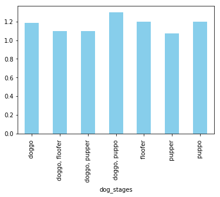

```python
# ok, in this dataframe there is some colums that describes it numerical values like its rating, favorite and
# retweet counts
# some coumns has got useful informations about content like text, source or dog breed and so on.
# it may be helpful for us to include different insights, so what about grouping contents by its dog stages and
# then look through their rating

df.groupby('dog_stages')['rating'].mean().plot.bar(color = 'skyblue');
```

> you can see there are several dog stages. and they looks like nearly equaly rated at first glance and might be its right, we make decision about it after our further investigations. So, let's move on.

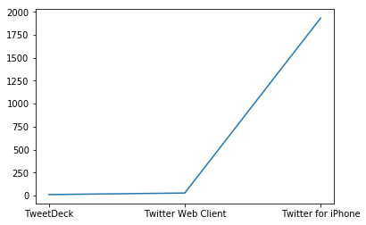

```python
# let's see which sources are most often used in our sample
plt.plot(df['source'].value_counts());
```

it looks like Twitter for iPhone is the most common among the users

[figure not shown]

```python
# so, let's see favorite count by time
plt.scatter(df['timestamp'], df['favorite_count'])
plt.xlabel('Time')
plt.ylabel('Favorites')
plt.show()
```

## So, what about our dogs, how we rate them to be fair?

> **Well, guys!** For rating dogs fairly, we must understand the terms used in dataset and can cope with them correctly. You have seen the dataset includes a lot of information and also several columns. If we use the information and columns effectively for rating our dogs, we can say 'we have been fair!'. Fair rating also very useful in the real world, because you can't be lead to wrong decisions and will get profit from that.

**So, let's understand a few concepts** about our dataframe, what does retweet and favorite mean?

- **favorite** : it means that someone agrees with your content
- **retweet** : it means that someone agrees strongly with your content and share this content with its followers

**The next** question, what is doggo, floofer, pupper and puppo?

- They are dog catigories in some social media, they are slang names for dog catigories to be more interesting, and now there is a DoggoLino dictionary ,which you can find more information about them, on the internet if you interested.

**And some questions again**, what text column is doing in our dog rate dataframe and what is expanded url?

- so, you must understand that we rate your dog according to its content text about it not your dog itself. Because everyone likes their dog and they don't need your ratings for them. They just want to rate their contents about them. Content texts are funny facts or something else. That is when we come to favorite or retweet.
- expanded url is the link that leads you to this content.

for now I think the other ones is understandable

```python
# let's try to identify which content is strongly agreed with others too,
# to do so we must do some loop to identify which has got more favorites and also retweets
most_favorite = 0
most_retweet = 0
for _ in range(df.shape[0]):
    if df['favorite_count'][_] > most_favorite and df['retweet_count'][_] > most_retweet:
        most_favorite = df['favorite_count'][_]
        most_retweet = df['retweet_count'][_]
        strongly_agreed_content = df.iloc[_]

# let's see the information about that content
strongly_agreed_content
```

```
tweet_id                                         822872901745569793
timestamp                                       2017-01-21 18:26:02
source                                           Twitter for iPhone
text              Here's a super supportive puppo participating ...
expanded_urls     https://twitter.com/dog_rates/status/822872901...
name                                                 Name not Given
dog_stages                                                   puppo
retweet_count                                                 48265
favorite_count                                               132810
jpg_url             https://pbs.twimg.com/media/C2tugXLXgAArJO4.jpg
img_num                                                           1
dog_breed                                          Lakeland Terrier
rating                                                          1.3
Name: 306, dtype: object
```

```python
# ok, we have found our winner on this rating, we can bring that content into our jupyter notebook
# but we need the full expanded url to handle that
# above we can't see it fully, so let's look closely at this url
strongly_agreed_content['expanded_urls']
```

```
'https://twitter.com/dog_rates/status/822872901745569793/photo/1'
```

```python
# ok, let's see our winner in right there, you know expanded url leads us to original content
# to do this we need to do some internet research
# find out how we do this
# ok we have found the code below, let's try it
#import json
import requests

class Tweet(object):
    def __init__(self, s, embed_str=False):
        if not embed_str:
            # Use Twitter's oEmbed API
            # https://dev.twitter.com/web/embedded-tweets
            api = 'https://publish.twitter.com/oembed?url={}'.format(s)
            response = requests.get(api)
            self.text = response.json()['html']
        else:
            self.text = s

    def _repr_html_(self):
        return self.text

Tweet('https://twitter.com/dog_rates/status/822872901745569793')
```

> Here's a super supportive puppo participating in the Toronto [#WomensMarch](https://twitter.com/hashtag/WomensMarch?src=hash&ref_src=twsrc%5Etfw) today. 13/10 [pic.twitter.com/nTz3FtorBc](https://t.co/nTz3FtorBc)

> — WeRateDogs® (@dog_rates) [January 21, 2017](https://twitter.com/dog_rates/status/822872901745569793?ref_src=twsrc%5Etfw)

> **Aha, here is our winner** do you like it! It is pretty, isn't it? Its name is not given too. Congrats! My friend, you are very lucky. A lot of people agrees with the comment about you. Ey guys! Are you also agree with that. If so, Its popularity widening again. Now, It's time to look at the data from other side. And finding new facts about them.

```python
# what about building a linear model to predict if a comment get more favorites,
# what is the potential of its retweeting
import statsmodels.api as sm

df['intercept'] = 1

lm = sm.OLS(df['retweet_count'], df[['intercept', 'favorite_count']])
result = lm.fit()
result.summary()
```

OLS Regression Results

| Dep. Variable: | retweet_count | R-squared: | 0.834 |
| --- | --- | --- | --- |
| Model: | OLS | Adj. R-squared: | 0.834 |
| Method: | Least Squares | F-statistic: | 9864. |
| Date: | Wed, 27 May 2020 | Prob (F-statistic): | 0.00 |
| Time: | 20:36:10 | Log-Likelihood: | -17693. |
| No. Observations: | 1971 | AIC: | 3.539e+04 |
| Df Residuals: | 1969 | BIC: | 3.540e+04 |
| Df Model: | 1 |  |  |
| Covariance Type: | nonrobust |  |  |

|  | coef | std err | t | P>\|t\| | [0.025 | 0.975] |
| --- | --- | --- | --- | --- | --- | --- |
| intercept | -344.3119 | 53.446 | -6.442 | 0.000 | -449.130 | -239.494 |
| favorite_count | 0.3496 | 0.004 | 99.316 | 0.000 | 0.343 | 0.357 |

| Omnibus: | 2198.695 | Durbin-Watson: | 1.343 |
| --- | --- | --- | --- |
| Prob(Omnibus): | 0.000 | Jarque-Bera (JB): | 525226.414 |
| Skew: | 5.175 | Prob(JB): | 0.00 |
| Kurtosis: | 82.299 | Cond. No. | 1.88e+04 |

**What about** seeing the relationship by scatterplot

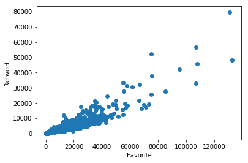

```python
plt.scatter(df['favorite_count'], df['retweet_count'])
plt.xlabel('Favorite')
plt.ylabel('Retweet')
plt.show()
```

It looks like Favorite and Retweet counts has strong positive correlation. That means, If your comment get more favourites there is a chance for it to be retweeted.

> For now I have run out of idea what to investigate. But you can continue further if you have more interesting ideas. You can do it yourself, because you have learnt a lot so far. And I think you can handle most of the tasks with the knowledge you learnt so far. For now It is time for me to **make conclusions** about what we have done.

# Conclusion

> **Ok, guys!** We are at the end of our journey to WeRateDogs dataset. I think you also had fun with this and learnt something useful. If so, I am happy with that. So, Let's start from the beginning. We have got a lot of raw data with different issues. And we need to solve these issues. I think we were able to handle them and prepared more clean data for our analysis. Then we made some insight on the dataset and find out some facts about them. Now, we can make some conclusions using them.

**For now**, congratulations our today's winner! Congrats, buddy!